# Untitled

2023-03-23

```r
# cargar la página web y almacenarla en un objeto llamado "pagina"
url <- "https://www.asexuality.org/en/topic/123256-asexuality-sexual-orientation-lexicon-read-me/"
pagina <- readLines(url)
#length(pagina)
#pagina
```

```r
indice = grep("Sexualities master list", pagina)
indice
```

```
## [1] 1322 4133
```

```r
pagina[1322]
```

```
## [1] "\t<u><span style=\"font-size:18px;\"><strong>Sexualities master list</strong></span></u>"
```

```r
alguito = pagina[4133]
alguito
```

```
## [1] "            \"text\": \"Sexualities master list\\n \\n\\n\\n\\tTHE 5 MAIN LABELS:\\n \\n\\n\\n\\tAsexual - A person who does not experience sexual attraction at all, but still might experience romantic or platonic attraction, and still may participate in sexual activities.\\n \\n\\n\\n\\t\\u…
```

```r
class(alguito)
```

```
## [1] "character"
```

```r
# Eliminar \n y \t utilizando gsub()
alguito_limpio<- gsub("\\\\[nt]", "", alguito)
alguito_limpio<- gsub("\\\\u00a0", "", alguito_limpio)
alguito_limpio<- gsub("\\\"text\\\": ", "", alguito_limpio)
alguito_limpio<- gsub("~*", "", alguito_limpio)
alguito_limpio<- gsub("[*]", "", alguito_limpio)
alguito_limpio<- gsub("\"", "", alguito_limpio)
alguito_limpio<- gsub("Sexualities master list THE 5 MAIN LABELS:", "", alguito_limpio)
alguito_limpio<- gsub("OTHER LABELS AND SUB-LABELS:", "", alguito_limpio)
alguito_limpio<- gsub("^\\s+|\\s+$|\\\\", "", alguito_limpio, perl = TRUE)
#alguito_limpio = unlist(strsplit(alguito_limpio, " - "))
#alguito_limpio = unlist(strsplit(alguito_limpio, "-"))
#alguito_limpio = unlist(strsplit(alguito_limpio, "\\."))

# Dividir el texto en palabras utilizando strsplit()
#palabras <- unlist(strsplit(alguito_limpio, " "))

# Imprimir las palabras
print(alguito_limpio)
```

```
## [1] "Asexual - A person who does not experience sexual attraction at all, but still might experience romantic or platonic attraction, and still may participate in sexual activities. Bisexual - A person who experiences sexual attraction to 2 or more genders Heterosexual - A person who experiences …
```

```r
vector_palabras = unlist(strsplit(alguito_limpio, " "))
vector_palabras[1:10]
```

```
##  [1] "Asexual"    "-"          "A"          "person"     "who"
##  [6] "does"       "not"        "experience" "sexual"     "attraction"
```

```r
i_g = c()
```

```r
descripcion_vec = c()
```

Asexual - A person who does not experience sexual attraction at all, but still might experience romantic or platonic attraction, and still may participate in sexual activities.

```r
ind_genero = grep("Asexual",vector_palabras)
ind_genero
```

```
## [1] 1
```

```r
i_g = c(i_g, vector_palabras[ind_genero])
i_g
```

```
## [1] "Asexual"
```

```r
descripcion = paste(vector_palabras[3:27],collapse = " ")
descripcion
```

```
## [1] "A person who does not experience sexual attraction at all, but still might experience romantic or platonic attraction, and still may participate in sexual activities."
```

```r
descripcion_vec = c(descripcion_vec,descripcion)
descripcion_vec
```

```
## [1] "A person who does not experience sexual attraction at all, but still might experience romantic or platonic attraction, and still may participate in sexual activities."
```

Bisexual - A person who experiences sexual attraction to 2 or more genders

```r
ind_genero = grep("Bisexual",vector_palabras)
ind_genero
```

```
## [1] 28
```

```r
i_g = c(i_g, vector_palabras[ind_genero])
i_g
```

```
## [1] "Asexual"  "Bisexual"
```

```r
descripcion = paste(vector_palabras[30:40],collapse = " ")
descripcion
```

```
## [1] "A person who experiences sexual attraction to 2 or more genders"
```

```r
descripcion_vec = c(descripcion_vec,descripcion)
descripcion_vec
```

```
## [1] "A person who does not experience sexual attraction at all, but still might experience romantic or platonic attraction, and still may participate in sexual activities."
## [2] "A person who experiences sexual attraction to 2 or more genders"
```

Heterosexual - A person who experiences sexual attraction to the opposite gender

```r
ind_genero = grep("Heterosexual",vector_palabras)
ind_genero
```

```
## [1] 41
```

```r
i_g = c(i_g, vector_palabras[ind_genero])
i_g
```

```
## [1] "Asexual"      "Bisexual"     "Heterosexual"
```

```r
descripcion = paste(vector_palabras[43:52],collapse = " ")
descripcion
```

```
## [1] "A person who experiences sexual attraction to the opposite gender"
```

```r
descripcion_vec = c(descripcion_vec,descripcion)
descripcion_vec
```

```
## [1] "A person who does not experience sexual attraction at all, but still might experience romantic or platonic attraction, and still may participate in sexual activities."
## [2] "A person who experiences sexual attraction to 2 or more genders"
## [3] "A person who experiences sexual attraction to the opposite gender"
```

Homosexual - A person who experiences sexual attraction to the same gender

```r
ind_genero = grep("Homosexual",vector_palabras)
ind_genero
```

```
## [1] 53
```

```r
i_g = c(i_g, vector_palabras[ind_genero])
i_g
```

```
## [1] "Asexual"      "Bisexual"     "Heterosexual" "Homosexual"
```

```r
descripcion = paste(vector_palabras[55:64],collapse = " ")
descripcion
```

```
## [1] "A person who experiences sexual attraction to the same gender"
```

```r
descripcion_vec = c(descripcion_vec,descripcion)
descripcion_vec
```

```
## [1] "A person who does not experience sexual attraction at all, but still might experience romantic or platonic attraction, and still may participate in sexual activities."
## [2] "A person who experiences sexual attraction to 2 or more genders"
## [3] "A person who experiences sexual attraction to the opposite gender"
## [4] "A person who experiences sexual attraction to the same gender"
```

Pansexual - A person who experiences sexual attraction to people regardless of their gender

```r
ind_genero = grep("Pansexual",vector_palabras)
ind_genero
```

```
## [1] 65
```

```r
i_g = c(i_g, vector_palabras[ind_genero])
i_g
```

```
## [1] "Asexual"      "Bisexual"     "Heterosexual" "Homosexual"   "Pansexual"
```

```r
descripcion = paste(vector_palabras[67:78],collapse = " ")
descripcion
```

```
## [1] "A person who experiences sexual attraction to people regardless of their gender"
```

```r
descripcion_vec = c(descripcion_vec,descripcion)
descripcion_vec
```

```
## [1] "A person who does not experience sexual attraction at all, but still might experience romantic or platonic attraction, and still may participate in sexual activities."
## [2] "A person who experiences sexual attraction to 2 or more genders"
## [3] "A person who experiences sexual attraction to the opposite gender"
## [4] "A person who experiences sexual attraction to the same gender"
## [5] "A person who experiences sexual attraction to people regardless of their gender"
```

Abrosexual- A person who experiences a fluid or rapidly changing sexual attraction to different gender expressions.

```r
ind_genero = grep("Abrosexual",vector_palabras)
ind_genero
```

```
## [1] 81
```

```r
vector = unlist(strsplit(vector_palabras[81], "-"))
vector
```

```
## [1] "Abrosexual"
```

```r
i_g = c(i_g, vector)
i_g
```

```
## [1] "Asexual"      "Bisexual"     "Heterosexual" "Homosexual"   "Pansexual"
## [6] "Abrosexual"
```

```r
descripcion = paste(vector_palabras[82:96],collapse = " ")
descripcion
```

```
## [1] "A person who experiences a fluid or rapidly changing sexual attraction to different gender expressions."
```

```r
descripcion_vec = c(descripcion_vec,descripcion)
descripcion_vec
```

```
## [1] "A person who does not experience sexual attraction at all, but still might experience romantic or platonic attraction, and still may participate in sexual activities."
## [2] "A person who experiences sexual attraction to 2 or more genders"
## [3] "A person who experiences sexual attraction to the opposite gender"
## [4] "A person who experiences sexual attraction to the same gender"
## [5] "A person who experiences sexual attraction to people regardless of their gender"
## [6] "A person who experiences a fluid or rapidly changing sexual attraction to different gender expressions."
```

Acosexual- A person whose negative experiences with sex has alienated them from their allo-romanticism

```r
ind_genero = grep("Acosexual",vector_palabras)
ind_genero
```

```
## [1] 97
```

```r
vector = unlist(strsplit(vector_palabras[97], "-"))
vector
```

```
## [1] "Acosexual"
```

```r
i_g = c(i_g, vector)
i_g
```

```
## [1] "Asexual"      "Bisexual"     "Heterosexual" "Homosexual"   "Pansexual"
## [6] "Abrosexual"   "Acosexual"
```

```r
descripcion = paste(vector_palabras[98:110],collapse = " ")
descripcion
```

```
## [1] "A person whose negative experiences with sex has alienated them from their allo-romanticism"
```

```r
descripcion_vec = c(descripcion_vec,descripcion)
descripcion_vec
```

```
## [1] "A person who does not experience sexual attraction at all, but still might experience romantic or platonic attraction, and still may participate in sexual activities."
## [2] "A person who experiences sexual attraction to 2 or more genders"
## [3] "A person who experiences sexual attraction to the opposite gender"
## [4] "A person who experiences sexual attraction to the same gender"
## [5] "A person who experiences sexual attraction to people regardless of their gender"
## [6] "A person who experiences a fluid or rapidly changing sexual attraction to different gender expressions."
## [7] "A person whose negative experiences with sex has alienated them from their allo-romanticism"
```

Adfectual/Adfectusexual/Affectusexual/Adfsexual- A person whose sexual attraction is affected by their neurodivergency

```r
ind_genero = grep("Adfectual",vector_palabras)
ind_genero
```

```
## [1] 111
```

```r
vector = unlist(strsplit(vector_palabras[111], "-"))
vector
```

```
## [1] "Adfectual/Adfectusexual/Affectusexual/Adfsexual"
```

```r
i_g = c(i_g, vector)
i_g
```

```
## [1] "Asexual"
## [2] "Bisexual"
## [3] "Heterosexual"
## [4] "Homosexual"
## [5] "Pansexual"
## [6] "Abrosexual"
## [7] "Acosexual"
## [8] "Adfectual/Adfectusexual/Affectusexual/Adfsexual"
```

```r
descripcion = paste(vector_palabras[112:121],collapse = " ")
descripcion
```

```
## [1] "A person whose sexual attraction is affected by their neurodivergency"
```

```r
descripcion_vec = c(descripcion_vec,descripcion)
descripcion_vec
```

```
## [1] "A person who does not experience sexual attraction at all, but still might experience romantic or platonic attraction, and still may participate in sexual activities."
## [2] "A person who experiences sexual attraction to 2 or more genders"
## [3] "A person who experiences sexual attraction to the opposite gender"
## [4] "A person who experiences sexual attraction to the same gender"
## [5] "A person who experiences sexual attraction to people regardless of their gender"
## [6] "A person who experiences a fluid or rapidly changing sexual attraction to different gender expressions."
## [7] "A person whose negative experiences with sex has alienated them from their allo-romanticism"
## [8] "A person whose sexual attraction is affected by their neurodivergency"
```

Aegosexual/Autochorissexual- A person with a disconnect between themselves and the target of their sexual attractions/desires

```r
ind_genero = grep("Aegosexual",vector_palabras)
ind_genero
```

```
## [1] 122
```

```r
vector = unlist(strsplit(vector_palabras[122], "-"))
vector
```

```
## [1] "Aegosexual/Autochorissexual"
```

```r
i_g = c(i_g, vector)
i_g
```

```
## [1] "Asexual"
## [2] "Bisexual"
## [3] "Heterosexual"
## [4] "Homosexual"
## [5] "Pansexual"
## [6] "Abrosexual"
## [7] "Acosexual"
## [8] "Adfectual/Adfectusexual/Affectusexual/Adfsexual"
## [9] "Aegosexual/Autochorissexual"
```

```r
descripcion = paste(vector_palabras[123:136],collapse = " ")
descripcion
```

```
## [1] "A person with a disconnect between themselves and the target of their sexual attractions/desires"
```

```r
descripcion_vec = c(descripcion_vec,descripcion)
descripcion_vec
```

```
## [1] "A person who does not experience sexual attraction at all, but still might experience romantic or platonic attraction, and still may participate in sexual activities."
## [2] "A person who experiences sexual attraction to 2 or more genders"
## [3] "A person who experiences sexual attraction to the opposite gender"
## [4] "A person who experiences sexual attraction to the same gender"
## [5] "A person who experiences sexual attraction to people regardless of their gender"
## [6] "A person who experiences a fluid or rapidly changing sexual attraction to different gender expressions."
## [7] "A person whose negative experiences with sex has alienated them from their allo-romanticism"
## [8] "A person whose sexual attraction is affected by their neurodivergency"
## [9] "A person with a disconnect between themselves and the target of their sexual attractions/desires"
```

Akoi(ne)sexual / Aposexual aka Lithsexual- A person who experiences sexual attraction to others but does not care or does not want that person to reciprocate

```r
ind_genero = grep("Akoi",vector_palabras)
ind_genero
```

```
## [1] 137
```

```r
vector = unlist(strsplit(vector_palabras[139:141], "-"))
vector = paste(vector, collapse = " ")
vector
```

```
## [1] "Aposexual aka Lithsexual"
```

```r
palabra = paste(vector_palabras[137:138], collapse = "")
palabra
```

```
## [1] "Akoi(ne)sexual/"
```

```r
vector = paste(palabra, vector, collapse = "")
vector
```

```
## [1] "Akoi(ne)sexual/ Aposexual aka Lithsexual"
```

```r
#palabras = paste(vector_palabras[139:141], collapse =
```

```r
i_g = c(i_g, vector)
i_g
```

```
##  [1] "Asexual"
##  [2] "Bisexual"
##  [3] "Heterosexual"
##  [4] "Homosexual"
##  [5] "Pansexual"
##  [6] "Abrosexual"
##  [7] "Acosexual"
##  [8] "Adfectual/Adfectusexual/Affectusexual/Adfsexual"
##  [9] "Aegosexual/Autochorissexual"
## [10] "Akoi(ne)sexual/ Aposexual aka Lithsexual"
```

```r
descripcion = paste(vector_palabras[142:161],collapse = " ")
descripcion
```

```
## [1] "A person who experiences sexual attraction to others but does not care or does not want that person to reciprocate"
```

```r
descripcion_vec = c(descripcion_vec,descripcion)
descripcion_vec
```

```
##  [1] "A person who does not experience sexual attraction at all, but still might experience romantic or platonic attraction, and still may participate in sexual activities."
##  [2] "A person who experiences sexual attraction to 2 or more genders"
##  [3] "A person who experiences sexual attraction to the opposite gender"
##  [4] "A person who experiences sexual attraction to the same gender"
##  [5] "A person who experiences sexual attraction to people regardless of their gender"
##  [6] "A person who experiences a fluid or rapidly changing sexual attraction to different gender expressions."
##  [7] "A person whose negative experiences with sex has alienated them from their allo-romanticism"
##  [8] "A person whose sexual attraction is affected by their neurodivergency"
##  [9] "A person with a disconnect between themselves and the target of their sexual attractions/desires"
## [10] "A person who experiences sexual attraction to others but does not care or does not want that person to reciprocate"
```

Allosexual- A person who experiences sexual attractions

```r
ind_genero = grep("Allosexual",vector_palabras)
ind_genero
```

```
## [1] 162
```

```r
vector = unlist(strsplit(vector_palabras[162], "-"))
vector
```

```
## [1] "Allosexual"
```

```r
i_g = c(i_g, vector)
i_g
```

```
##  [1] "Asexual"
##  [2] "Bisexual"
##  [3] "Heterosexual"
##  [4] "Homosexual"
##  [5] "Pansexual"
##  [6] "Abrosexual"
##  [7] "Acosexual"
##  [8] "Adfectual/Adfectusexual/Affectusexual/Adfsexual"
##  [9] "Aegosexual/Autochorissexual"
## [10] "Akoi(ne)sexual/ Aposexual aka Lithsexual"
## [11] "Allosexual"
```

```r
descripcion = paste(vector_palabras[163:168],collapse = " ")
descripcion
```

```
## [1] "A person who experiences sexual attractions"
```

```r
descripcion_vec = c(descripcion_vec,descripcion)
descripcion_vec
```

```
##  [1] "A person who does not experience sexual attraction at all, but still might experience romantic or platonic attraction, and still may participate in sexual activities."
##  [2] "A person who experiences sexual attraction to 2 or more genders"
##  [3] "A person who experiences sexual attraction to the opposite gender"
##  [4] "A person who experiences sexual attraction to the same gender"
##  [5] "A person who experiences sexual attraction to people regardless of their gender"
##  [6] "A person who experiences a fluid or rapidly changing sexual attraction to different gender expressions."
##  [7] "A person whose negative experiences with sex has alienated them from their allo-romanticism"
##  [8] "A person whose sexual attraction is affected by their neurodivergency"
##  [9] "A person with a disconnect between themselves and the target of their sexual attractions/desires"
## [10] "A person who experiences sexual attraction to others but does not care or does not want that person to reciprocate"
## [11] "A person who experiences sexual attractions"
```

Androgynosexual - A person who is attracted to androgynous people

```r
ind_genero = grep("Androgynosexual",vector_palabras)
ind_genero
```

```
## [1] 169
```

```r
i_g = c(i_g, vector_palabras[ind_genero])
i_g
```

```
##  [1] "Asexual"
##  [2] "Bisexual"
##  [3] "Heterosexual"
##  [4] "Homosexual"
##  [5] "Pansexual"
##  [6] "Abrosexual"
##  [7] "Acosexual"
##  [8] "Adfectual/Adfectusexual/Affectusexual/Adfsexual"
##  [9] "Aegosexual/Autochorissexual"
## [10] "Akoi(ne)sexual/ Aposexual aka Lithsexual"
## [11] "Allosexual"
## [12] "Androgynosexual"
```

```r
descripcion = paste(vector_palabras[171:178],collapse = " ")
descripcion
```

```
## [1] "A person who is attracted to androgynous people"
```

```r
descripcion_vec = c(descripcion_vec,descripcion)
descripcion_vec
```

```
##  [1] "A person who does not experience sexual attraction at all, but still might experience romantic or platonic attraction, and still may participate in sexual activities."
##  [2] "A person who experiences sexual attraction to 2 or more genders"
##  [3] "A person who experiences sexual attraction to the opposite gender"
##  [4] "A person who experiences sexual attraction to the same gender"
##  [5] "A person who experiences sexual attraction to people regardless of their gender"
##  [6] "A person who experiences a fluid or rapidly changing sexual attraction to different gender expressions."
##  [7] "A person whose negative experiences with sex has alienated them from their allo-romanticism"
##  [8] "A person whose sexual attraction is affected by their neurodivergency"
##  [9] "A person with a disconnect between themselves and the target of their sexual attractions/desires"
## [10] "A person who experiences sexual attraction to others but does not care or does not want that person to reciprocate"
## [11] "A person who experiences sexual attractions"
## [12] "A person who is attracted to androgynous people"
```

Androsexual - A person who is sexually attracted to males

```r
ind_genero = grep("Androsexual",vector_palabras)
ind_genero
```

```
## [1] 179
```

```r
i_g = c(i_g, vector_palabras[ind_genero])
i_g
```

```
##  [1] "Asexual"
##  [2] "Bisexual"
##  [3] "Heterosexual"
##  [4] "Homosexual"
##  [5] "Pansexual"
##  [6] "Abrosexual"
##  [7] "Acosexual"
##  [8] "Adfectual/Adfectusexual/Affectusexual/Adfsexual"
##  [9] "Aegosexual/Autochorissexual"
## [10] "Akoi(ne)sexual/ Aposexual aka Lithsexual"
## [11] "Allosexual"
## [12] "Androgynosexual"
## [13] "Androsexual"
```

```r
descripcion = paste(vector_palabras[181:188],collapse = " ")
descripcion
```

```
## [1] "A person who is sexually attracted to males"
```

```r
descripcion_vec = c(descripcion_vec,descripcion)
descripcion_vec
```

```
##  [1] "A person who does not experience sexual attraction at all, but still might experience romantic or platonic attraction, and still may participate in sexual activities."
##  [2] "A person who experiences sexual attraction to 2 or more genders"
##  [3] "A person who experiences sexual attraction to the opposite gender"
##  [4] "A person who experiences sexual attraction to the same gender"
##  [5] "A person who experiences sexual attraction to people regardless of their gender"
##  [6] "A person who experiences a fluid or rapidly changing sexual attraction to different gender expressions."
##  [7] "A person whose negative experiences with sex has alienated them from their allo-romanticism"
##  [8] "A person whose sexual attraction is affected by their neurodivergency"
##  [9] "A person with a disconnect between themselves and the target of their sexual attractions/desires"
## [10] "A person who experiences sexual attraction to others but does not care or does not want that person to reciprocate"
## [11] "A person who experiences sexual attractions"
## [12] "A person who is attracted to androgynous people"
## [13] "A person who is sexually attracted to males"
```

Antisexual - A person who is opposed to sexuality

```r
ind_genero = grep("Antisexual",vector_palabras)
ind_genero
```

```
## [1] 189
```

```r
i_g = c(i_g, vector_palabras[ind_genero])
i_g
```

```
##  [1] "Asexual"
##  [2] "Bisexual"
##  [3] "Heterosexual"
##  [4] "Homosexual"
##  [5] "Pansexual"
##  [6] "Abrosexual"
##  [7] "Acosexual"
##  [8] "Adfectual/Adfectusexual/Affectusexual/Adfsexual"
##  [9] "Aegosexual/Autochorissexual"
## [10] "Akoi(ne)sexual/ Aposexual aka Lithsexual"
## [11] "Allosexual"
## [12] "Androgynosexual"
## [13] "Androsexual"
## [14] "Antisexual"
```

```r
descripcion = paste(vector_palabras[191:197],collapse = " ")
descripcion
```

```
## [1] "A person who is opposed to sexuality"
```

```r
descripcion_vec = c(descripcion_vec,descripcion)
descripcion_vec
```

```
##  [1] "A person who does not experience sexual attraction at all, but still might experience romantic or platonic attraction, and still may participate in sexual activities."
##  [2] "A person who experiences sexual attraction to 2 or more genders"
##  [3] "A person who experiences sexual attraction to the opposite gender"
##  [4] "A person who experiences sexual attraction to the same gender"
##  [5] "A person who experiences sexual attraction to people regardless of their gender"
##  [6] "A person who experiences a fluid or rapidly changing sexual attraction to different gender expressions."
##  [7] "A person whose negative experiences with sex has alienated them from their allo-romanticism"
##  [8] "A person whose sexual attraction is affected by their neurodivergency"
##  [9] "A person with a disconnect between themselves and the target of their sexual attractions/desires"
## [10] "A person who experiences sexual attraction to others but does not care or does not want that person to reciprocate"
## [11] "A person who experiences sexual attractions"
## [12] "A person who is attracted to androgynous people"
## [13] "A person who is sexually attracted to males"
## [14] "A person who is opposed to sexuality"
```

Apathsexual- A person who is indifferent/apathetic to sexual attraction

```r
ind_genero = grep("Apathsexual",vector_palabras)
ind_genero
```

```
## [1] 198
```

```r
vector = unlist(strsplit(vector_palabras[198], "-"))
vector
```

```
## [1] "Apathsexual"
```

```r
i_g = c(i_g, vector)
i_g
```

```
##  [1] "Asexual"
##  [2] "Bisexual"
##  [3] "Heterosexual"
##  [4] "Homosexual"
##  [5] "Pansexual"
##  [6] "Abrosexual"
##  [7] "Acosexual"
##  [8] "Adfectual/Adfectusexual/Affectusexual/Adfsexual"
##  [9] "Aegosexual/Autochorissexual"
## [10] "Akoi(ne)sexual/ Aposexual aka Lithsexual"
## [11] "Allosexual"
## [12] "Androgynosexual"
## [13] "Androsexual"
## [14] "Antisexual"
## [15] "Apathsexual"
```

```r
descripcion = paste(vector_palabras[199:206],collapse = " ")
descripcion
```

```
## [1] "A person who is indifferent/apathetic to sexual attraction"
```

```r
descripcion_vec = c(descripcion_vec,descripcion)
descripcion_vec
```

```
##  [1] "A person who does not experience sexual attraction at all, but still might experience romantic or platonic attraction, and still may participate in sexual activities."
##  [2] "A person who experiences sexual attraction to 2 or more genders"
##  [3] "A person who experiences sexual attraction to the opposite gender"
##  [4] "A person who experiences sexual attraction to the same gender"
##  [5] "A person who experiences sexual attraction to people regardless of their gender"
##  [6] "A person who experiences a fluid or rapidly changing sexual attraction to different gender expressions."
##  [7] "A person whose negative experiences with sex has alienated them from their allo-romanticism"
##  [8] "A person whose sexual attraction is affected by their neurodivergency"
##  [9] "A person with a disconnect between themselves and the target of their sexual attractions/desires"
## [10] "A person who experiences sexual attraction to others but does not care or does not want that person to reciprocate"
## [11] "A person who experiences sexual attractions"
## [12] "A person who is attracted to androgynous people"
## [13] "A person who is sexually attracted to males"
## [14] "A person who is opposed to sexuality"
## [15] "A person who is indifferent/apathetic to sexual attraction"
```

Apothisexual - A person who does not experiences sexual attraction and does not want others to be sexually involved with them

```r
ind_genero = grep("Apothisexual",vector_palabras)
ind_genero
```

```
## [1] 207
```

```r
i_g = c(i_g, vector_palabras[ind_genero])
i_g
```

```
##  [1] "Asexual"
##  [2] "Bisexual"
##  [3] "Heterosexual"
##  [4] "Homosexual"
##  [5] "Pansexual"
##  [6] "Abrosexual"
##  [7] "Acosexual"
##  [8] "Adfectual/Adfectusexual/Affectusexual/Adfsexual"
##  [9] "Aegosexual/Autochorissexual"
## [10] "Akoi(ne)sexual/ Aposexual aka Lithsexual"
## [11] "Allosexual"
## [12] "Androgynosexual"
## [13] "Androsexual"
## [14] "Antisexual"
## [15] "Apathsexual"
## [16] "Apothisexual"
```

```r
descripcion = paste(vector_palabras[209:227],collapse = " ")
descripcion
```

```
## [1] "A person who does not experiences sexual attraction and does not want others to be sexually involved with them"
```

```r
descripcion_vec = c(descripcion_vec,descripcion)
descripcion_vec
```

```
##  [1] "A person who does not experience sexual attraction at all, but still might experience romantic or platonic attraction, and still may participate in sexual activities."
##  [2] "A person who experiences sexual attraction to 2 or more genders"
##  [3] "A person who experiences sexual attraction to the opposite gender"
##  [4] "A person who experiences sexual attraction to the same gender"
##  [5] "A person who experiences sexual attraction to people regardless of their gender"
##  [6] "A person who experiences a fluid or rapidly changing sexual attraction to different gender expressions."
##  [7] "A person whose negative experiences with sex has alienated them from their allo-romanticism"
##  [8] "A person whose sexual attraction is affected by their neurodivergency"
##  [9] "A person with a disconnect between themselves and the target of their sexual attractions/desires"
## [10] "A person who experiences sexual attraction to others but does not care or does not want that person to reciprocate"
## [11] "A person who experiences sexual attractions"
## [12] "A person who is attracted to androgynous people"
## [13] "A person who is sexually attracted to males"
## [14] "A person who is opposed to sexuality"
## [15] "A person who is indifferent/apathetic to sexual attraction"
## [16] "A person who does not experiences sexual attraction and does not want others to be sexually involved with them"
```

Apressexual- A person who only experiences a sexual attraction after another form of attraction is felt. The original attraction may or may not fade/be replaced by the new attraction.

```r
ind_genero = grep("Apressexual",vector_palabras)
ind_genero
```

```
## [1] 228
```

```r
vector = unlist(strsplit(vector_palabras[228], "-"))
vector
```

```
## [1] "Apressexual"
```

```r
i_g = c(i_g, vector)
i_g
```

```
##  [1] "Asexual"
##  [2] "Bisexual"
##  [3] "Heterosexual"
##  [4] "Homosexual"
##  [5] "Pansexual"
##  [6] "Abrosexual"
##  [7] "Acosexual"
##  [8] "Adfectual/Adfectusexual/Affectusexual/Adfsexual"
##  [9] "Aegosexual/Autochorissexual"
## [10] "Akoi(ne)sexual/ Aposexual aka Lithsexual"
## [11] "Allosexual"
## [12] "Androgynosexual"
## [13] "Androsexual"
## [14] "Antisexual"
## [15] "Apathsexual"
## [16] "Apothisexual"
## [17] "Apressexual"
```

```r
descripcion = paste(vector_palabras[229:256],collapse = " ")
descripcion
```

```
## [1] "A person who only experiences a sexual attraction after another form of attraction is felt. The original attraction may or may not fade/be replaced by the new attraction."
```

```r
descripcion_vec = c(descripcion_vec,descripcion)
descripcion_vec
```

```
##  [1] "A person who does not experience sexual attraction at all, but still might experience romantic or platonic attraction, and still may participate in sexual activities."
##  [2] "A person who experiences sexual attraction to 2 or more genders"
##  [3] "A person who experiences sexual attraction to the opposite gender"
##  [4] "A person who experiences sexual attraction to the same gender"
##  [5] "A person who experiences sexual attraction to people regardless of their gender"
##  [6] "A person who experiences a fluid or rapidly changing sexual attraction to different gender expressions."
##  [7] "A person whose negative experiences with sex has alienated them from their allo-romanticism"
##  [8] "A person whose sexual attraction is affected by their neurodivergency"
##  [9] "A person with a disconnect between themselves and the target of their sexual attractions/desires"
## [10] "A person who experiences sexual attraction to others but does not care or does not want that person to reciprocate"
## [11] "A person who experiences sexual attractions"
## [12] "A person who is attracted to androgynous people"
## [13] "A person who is sexually attracted to males"
## [14] "A person who is opposed to sexuality"
## [15] "A person who is indifferent/apathetic to sexual attraction"
## [16] "A person who does not experiences sexual attraction and does not want others to be sexually involved with them"
## [17] "A person who only experiences a sexual attraction after another form of attraction is felt. The original attraction may or may not fade/be replaced by the new attraction."
```

Autosexual - A person who is sexually attracted to oneself, or a person who can experience sexual satisfaction mainly through masturbation

```r
ind_genero = grep("Autosexual",vector_palabras)
ind_genero
```

```
## [1] 257
```

```r
i_g = c(i_g, vector_palabras[ind_genero])
i_g
```

```
##  [1] "Asexual"
##  [2] "Bisexual"
##  [3] "Heterosexual"
##  [4] "Homosexual"
##  [5] "Pansexual"
##  [6] "Abrosexual"
##  [7] "Acosexual"
##  [8] "Adfectual/Adfectusexual/Affectusexual/Adfsexual"
##  [9] "Aegosexual/Autochorissexual"
## [10] "Akoi(ne)sexual/ Aposexual aka Lithsexual"
## [11] "Allosexual"
## [12] "Androgynosexual"
## [13] "Androsexual"
## [14] "Antisexual"
## [15] "Apathsexual"
## [16] "Apothisexual"
## [17] "Apressexual"
## [18] "Autosexual"
```

```r
descripcion = paste(vector_palabras[259:277],collapse = " ")
descripcion
```

```
## [1] "A person who is sexually attracted to oneself, or a person who can experience sexual satisfaction mainly through masturbation"
```

```r
descripcion_vec = c(descripcion_vec,descripcion)
descripcion_vec
```

```
##  [1] "A person who does not experience sexual attraction at all, but still might experience romantic or platonic attraction, and still may participate in sexual activities."
##  [2] "A person who experiences sexual attraction to 2 or more genders"
##  [3] "A person who experiences sexual attraction to the opposite gender"
##  [4] "A person who experiences sexual attraction to the same gender"
##  [5] "A person who experiences sexual attraction to people regardless of their gender"
##  [6] "A person who experiences a fluid or rapidly changing sexual attraction to different gender expressions."
##  [7] "A person whose negative experiences with sex has alienated them from their allo-romanticism"
##  [8] "A person whose sexual attraction is affected by their neurodivergency"
##  [9] "A person with a disconnect between themselves and the target of their sexual attractions/desires"
## [10] "A person who experiences sexual attraction to others but does not care or does not want that person to reciprocate"
## [11] "A person who experiences sexual attractions"
## [12] "A person who is attracted to androgynous people"
## [13] "A person who is sexually attracted to males"
## [14] "A person who is opposed to sexuality"
## [15] "A person who is indifferent/apathetic to sexual attraction"
## [16] "A person who does not experiences sexual attraction and does not want others to be sexually involved with them"
## [17] "A person who only experiences a sexual attraction after another form of attraction is felt. The original attraction may or may not fade/be replaced by the new attraction."
## [18] "A person who is sexually attracted to oneself, or a person who can experience sexual satisfaction mainly through masturbation"
```

Bellussexual- A person who enjoys the endearing aesthetics of romance/sexual courtship but does not want a sexual relationship.

```r
ind_genero = grep("Bellussexual",vector_palabras)
ind_genero
```

```
## [1] 278
```

```r
vector = unlist(strsplit(vector_palabras[278], "-"))
vector
```

```
## [1] "Bellussexual"
```

```r
i_g = c(i_g, vector)
i_g
```

```
##  [1] "Asexual"
##  [2] "Bisexual"
##  [3] "Heterosexual"
##  [4] "Homosexual"
##  [5] "Pansexual"
##  [6] "Abrosexual"
##  [7] "Acosexual"
##  [8] "Adfectual/Adfectusexual/Affectusexual/Adfsexual"
##  [9] "Aegosexual/Autochorissexual"
## [10] "Akoi(ne)sexual/ Aposexual aka Lithsexual"
## [11] "Allosexual"
## [12] "Androgynosexual"
## [13] "Androsexual"
## [14] "Antisexual"
## [15] "Apathsexual"
## [16] "Apothisexual"
## [17] "Apressexual"
## [18] "Autosexual"
## [19] "Bellussexual"
```

```r
descripcion = paste(vector_palabras[279:295],collapse = " ")
descripcion
```

```
## [1] "A person who enjoys the endearing aesthetics of romance/sexual courtship but does not want a sexual relationship."
```

```r
descripcion_vec = c(descripcion_vec,descripcion)
descripcion_vec
```

```
##  [1] "A person who does not experience sexual attraction at all, but still might experience romantic or platonic attraction, and still may participate in sexual activities."
##  [2] "A person who experiences sexual attraction to 2 or more genders"
##  [3] "A person who experiences sexual attraction to the opposite gender"
##  [4] "A person who experiences sexual attraction to the same gender"
##  [5] "A person who experiences sexual attraction to people regardless of their gender"
##  [6] "A person who experiences a fluid or rapidly changing sexual attraction to different gender expressions."
##  [7] "A person whose negative experiences with sex has alienated them from their allo-romanticism"
##  [8] "A person whose sexual attraction is affected by their neurodivergency"
##  [9] "A person with a disconnect between themselves and the target of their sexual attractions/desires"
## [10] "A person who experiences sexual attraction to others but does not care or does not want that person to reciprocate"
## [11] "A person who experiences sexual attractions"
## [12] "A person who is attracted to androgynous people"
## [13] "A person who is sexually attracted to males"
## [14] "A person who is opposed to sexuality"
## [15] "A person who is indifferent/apathetic to sexual attraction"
## [16] "A person who does not experiences sexual attraction and does not want others to be sexually involved with them"
## [17] "A person who only experiences a sexual attraction after another form of attraction is felt. The original attraction may or may not fade/be replaced by the new attraction."
## [18] "A person who is sexually attracted to oneself, or a person who can experience sexual satisfaction mainly through masturbation"
## [19] "A person who enjoys the endearing aesthetics of romance/sexual courtship but does not want a sexual relationship."
```

Boreasexual- A person who has a set sexual orientation but with an exception

```r
ind_genero = grep("Boreasexual",vector_palabras)
ind_genero
```

```
## [1] 296
```

```r
vector = unlist(strsplit(vector_palabras[296], "-"))
vector
```

```
## [1] "Boreasexual"
```

```r
i_g = c(i_g, vector)
i_g
```

```
##  [1] "Asexual"
##  [2] "Bisexual"
##  [3] "Heterosexual"
##  [4] "Homosexual"
##  [5] "Pansexual"
##  [6] "Abrosexual"
##  [7] "Acosexual"
##  [8] "Adfectual/Adfectusexual/Affectusexual/Adfsexual"
##  [9] "Aegosexual/Autochorissexual"
## [10] "Akoi(ne)sexual/ Aposexual aka Lithsexual"
## [11] "Allosexual"
## [12] "Androgynosexual"
## [13] "Androsexual"
## [14] "Antisexual"
## [15] "Apathsexual"
## [16] "Apothisexual"
## [17] "Apressexual"
## [18] "Autosexual"
## [19] "Bellussexual"
## [20] "Boreasexual"
```

```r
descripcion = paste(vector_palabras[297:308],collapse = " ")
descripcion
```

```
## [1] "A person who has a set sexual orientation but with an exception"
```

```r
descripcion_vec = c(descripcion_vec,descripcion)
descripcion_vec
```

```
##  [1] "A person who does not experience sexual attraction at all, but still might experience romantic or platonic attraction, and still may participate in sexual activities."
##  [2] "A person who experiences sexual attraction to 2 or more genders"
##  [3] "A person who experiences sexual attraction to the opposite gender"
##  [4] "A person who experiences sexual attraction to the same gender"
##  [5] "A person who experiences sexual attraction to people regardless of their gender"
##  [6] "A person who experiences a fluid or rapidly changing sexual attraction to different gender expressions."
##  [7] "A person whose negative experiences with sex has alienated them from their allo-romanticism"
##  [8] "A person whose sexual attraction is affected by their neurodivergency"
##  [9] "A person with a disconnect between themselves and the target of their sexual attractions/desires"
## [10] "A person who experiences sexual attraction to others but does not care or does not want that person to reciprocate"
## [11] "A person who experiences sexual attractions"
## [12] "A person who is attracted to androgynous people"
## [13] "A person who is sexually attracted to males"
## [14] "A person who is opposed to sexuality"
## [15] "A person who is indifferent/apathetic to sexual attraction"
## [16] "A person who does not experiences sexual attraction and does not want others to be sexually involved with them"
## [17] "A person who only experiences a sexual attraction after another form of attraction is felt. The original attraction may or may not fade/be replaced by the new attraction."
## [18] "A person who is sexually attracted to oneself, or a person who can experience sexual satisfaction mainly through masturbation"
## [19] "A person who enjoys the endearing aesthetics of romance/sexual courtship but does not want a sexual relationship."
## [20] "A person who has a set sexual orientation but with an exception"
```

Burstsexual - A person who experiences sudden idiopathic and sporadic episodes of sexual attraction.

```r
ind_genero = grep("Burstsexual",vector_palabras)
ind_genero
```

```
## [1] 309
```

```r
i_g = c(i_g, vector_palabras[ind_genero])
i_g
```

```
##  [1] "Asexual"
##  [2] "Bisexual"
##  [3] "Heterosexual"
##  [4] "Homosexual"
##  [5] "Pansexual"
##  [6] "Abrosexual"
##  [7] "Acosexual"
##  [8] "Adfectual/Adfectusexual/Affectusexual/Adfsexual"
##  [9] "Aegosexual/Autochorissexual"
## [10] "Akoi(ne)sexual/ Aposexual aka Lithsexual"
## [11] "Allosexual"
## [12] "Androgynosexual"
## [13] "Androsexual"
## [14] "Antisexual"
## [15] "Apathsexual"
## [16] "Apothisexual"
## [17] "Apressexual"
## [18] "Autosexual"
## [19] "Bellussexual"
## [20] "Boreasexual"
## [21] "Burstsexual"
```

```r
descripcion = paste(vector_palabras[311:322],collapse = " ")
descripcion
```

```
## [1] "A person who experiences sudden idiopathic and sporadic episodes of sexual attraction."
```

```r
descripcion_vec = c(descripcion_vec,descripcion)
descripcion_vec
```

```
##  [1] "A person who does not experience sexual attraction at all, but still might experience romantic or platonic attraction, and still may participate in sexual activities."
##  [2] "A person who experiences sexual attraction to 2 or more genders"
##  [3] "A person who experiences sexual attraction to the opposite gender"
##  [4] "A person who experiences sexual attraction to the same gender"
##  [5] "A person who experiences sexual attraction to people regardless of their gender"
##  [6] "A person who experiences a fluid or rapidly changing sexual attraction to different gender expressions."
##  [7] "A person whose negative experiences with sex has alienated them from their allo-romanticism"
##  [8] "A person whose sexual attraction is affected by their neurodivergency"
##  [9] "A person with a disconnect between themselves and the target of their sexual attractions/desires"
## [10] "A person who experiences sexual attraction to others but does not care or does not want that person to reciprocate"
## [11] "A person who experiences sexual attractions"
## [12] "A person who is attracted to androgynous people"
## [13] "A person who is sexually attracted to males"
## [14] "A person who is opposed to sexuality"
## [15] "A person who is indifferent/apathetic to sexual attraction"
## [16] "A person who does not experiences sexual attraction and does not want others to be sexually involved with them"
## [17] "A person who only experiences a sexual attraction after another form of attraction is felt. The original attraction may or may not fade/be replaced by the new attraction."
## [18] "A person who is sexually attracted to oneself, or a person who can experience sexual satisfaction mainly through masturbation"
## [19] "A person who enjoys the endearing aesthetics of romance/sexual courtship but does not want a sexual relationship."
## [20] "A person who has a set sexual orientation but with an exception"
## [21] "A person who experiences sudden idiopathic and sporadic episodes of sexual attraction."
```

Caedsexual/Kalossexual- A person who used to experience sexual attractions, but no longer does due to past trauma.

```r
ind_genero = grep("Caedsexual/Kalossexual", vector_palabras)
ind_genero
```

```
## [1] 323
```

```r
i_g = c(i_g, vector_palabras[ind_genero])
i_g
```

```
##  [1] "Asexual"
##  [2] "Bisexual"
##  [3] "Heterosexual"
##  [4] "Homosexual"
##  [5] "Pansexual"
##  [6] "Abrosexual"
##  [7] "Acosexual"
##  [8] "Adfectual/Adfectusexual/Affectusexual/Adfsexual"
##  [9] "Aegosexual/Autochorissexual"
## [10] "Akoi(ne)sexual/ Aposexual aka Lithsexual"
## [11] "Allosexual"
## [12] "Androgynosexual"
## [13] "Androsexual"
## [14] "Antisexual"
## [15] "Apathsexual"
## [16] "Apothisexual"
## [17] "Apressexual"
## [18] "Autosexual"
## [19] "Bellussexual"
## [20] "Boreasexual"
## [21] "Burstsexual"
## [22] "Caedsexual/Kalossexual-"
```

```r
descripcion = paste(vector_palabras[324:339],collapse = " ")
descripcion
```

```
## [1] "A person who used to experience sexual attractions, but no longer does due to past trauma."
```

```r
descripcion_vec = c(descripcion_vec,descripcion)
descripcion_vec
```

```
##  [1] "A person who does not experience sexual attraction at all, but still might experience romantic or platonic attraction, and still may participate in sexual activities."
##  [2] "A person who experiences sexual attraction to 2 or more genders"
##  [3] "A person who experiences sexual attraction to the opposite gender"
##  [4] "A person who experiences sexual attraction to the same gender"
##  [5] "A person who experiences sexual attraction to people regardless of their gender"
##  [6] "A person who experiences a fluid or rapidly changing sexual attraction to different gender expressions."
##  [7] "A person whose negative experiences with sex has alienated them from their allo-romanticism"
##  [8] "A person whose sexual attraction is affected by their neurodivergency"
##  [9] "A person with a disconnect between themselves and the target of their sexual attractions/desires"
## [10] "A person who experiences sexual attraction to others but does not care or does not want that person to reciprocate"
## [11] "A person who experiences sexual attractions"
## [12] "A person who is attracted to androgynous people"
## [13] "A person who is sexually attracted to males"
## [14] "A person who is opposed to sexuality"
## [15] "A person who is indifferent/apathetic to sexual attraction"
## [16] "A person who does not experiences sexual attraction and does not want others to be sexually involved with them"
## [17] "A person who only experiences a sexual attraction after another form of attraction is felt. The original attraction may or may not fade/be replaced by the new attraction."
## [18] "A person who is sexually attracted to oneself, or a person who can experience sexual satisfaction mainly through masturbation"
## [19] "A person who enjoys the endearing aesthetics of romance/sexual courtship but does not want a sexual relationship."
## [20] "A person who has a set sexual orientation but with an exception"
## [21] "A person who experiences sudden idiopathic and sporadic episodes of sexual attraction."
## [22] "A person who used to experience sexual attractions, but no longer does due to past trauma."
```

Cupiosexual - A person who does not experience sexual attractions but wants to be in a sexual relationship

```r
ind_genero = grep("Cupiosexual", vector_palabras)
ind_genero
```

```
## [1] 340
```

```r
i_g = c(i_g, vector_palabras[ind_genero])
i_g
```

```
##  [1] "Asexual"
##  [2] "Bisexual"
##  [3] "Heterosexual"
##  [4] "Homosexual"
##  [5] "Pansexual"
##  [6] "Abrosexual"
##  [7] "Acosexual"
##  [8] "Adfectual/Adfectusexual/Affectusexual/Adfsexual"
##  [9] "Aegosexual/Autochorissexual"
## [10] "Akoi(ne)sexual/ Aposexual aka Lithsexual"
## [11] "Allosexual"
## [12] "Androgynosexual"
## [13] "Androsexual"
## [14] "Antisexual"
## [15] "Apathsexual"
## [16] "Apothisexual"
## [17] "Apressexual"
## [18] "Autosexual"
## [19] "Bellussexual"
## [20] "Boreasexual"
## [21] "Burstsexual"
## [22] "Caedsexual/Kalossexual-"
## [23] "Cupiosexual"
```

```r
descripcion = paste(vector_palabras[342:357],collapse = " ")
descripcion
```

```
## [1] "A person who does not experience sexual attractions but wants to be in a sexual relationship"
```

```r
descripcion_vec = c(descripcion_vec,descripcion)
descripcion_vec
```

```
##  [1] "A person who does not experience sexual attraction at all, but still might experience romantic or platonic attraction, and still may participate in sexual activities."
##  [2] "A person who experiences sexual attraction to 2 or more genders"
##  [3] "A person who experiences sexual attraction to the opposite gender"
##  [4] "A person who experiences sexual attraction to the same gender"
##  [5] "A person who experiences sexual attraction to people regardless of their gender"
##  [6] "A person who experiences a fluid or rapidly changing sexual attraction to different gender expressions."
##  [7] "A person whose negative experiences with sex has alienated them from their allo-romanticism"
##  [8] "A person whose sexual attraction is affected by their neurodivergency"
##  [9] "A person with a disconnect between themselves and the target of their sexual attractions/desires"
## [10] "A person who experiences sexual attraction to others but does not care or does not want that person to reciprocate"
## [11] "A person who experiences sexual attractions"
## [12] "A person who is attracted to androgynous people"
## [13] "A person who is sexually attracted to males"
## [14] "A person who is opposed to sexuality"
## [15] "A person who is indifferent/apathetic to sexual attraction"
## [16] "A person who does not experiences sexual attraction and does not want others to be sexually involved with them"
## [17] "A person who only experiences a sexual attraction after another form of attraction is felt. The original attraction may or may not fade/be replaced by the new attraction."
## [18] "A person who is sexually attracted to oneself, or a person who can experience sexual satisfaction mainly through masturbation"
## [19] "A person who enjoys the endearing aesthetics of romance/sexual courtship but does not want a sexual relationship."
## [20] "A person who has a set sexual orientation but with an exception"
## [21] "A person who experiences sudden idiopathic and sporadic episodes of sexual attraction."
## [22] "A person who used to experience sexual attractions, but no longer does due to past trauma."
## [23] "A person who does not experience sexual attractions but wants to be in a sexual relationship"
```

Demisexual - A person who only become sexually attracted to someone else after creating a strong emotional bond with that person. The sexual attraction does not exist before the two have created an emotional bond. (opposite of fraysexual)

```r
ind_genero = grep("Demisexual",vector_palabras)
ind_genero
```

```
## [1] 358
```

```r
i_g = c(i_g, vector_palabras[ind_genero])
i_g
```

```
##  [1] "Asexual"
##  [2] "Bisexual"
##  [3] "Heterosexual"
##  [4] "Homosexual"
##  [5] "Pansexual"
##  [6] "Abrosexual"
##  [7] "Acosexual"
##  [8] "Adfectual/Adfectusexual/Affectusexual/Adfsexual"
##  [9] "Aegosexual/Autochorissexual"
## [10] "Akoi(ne)sexual/ Aposexual aka Lithsexual"
## [11] "Allosexual"
## [12] "Androgynosexual"
## [13] "Androsexual"
## [14] "Antisexual"
## [15] "Apathsexual"
## [16] "Apothisexual"
## [17] "Apressexual"
## [18] "Autosexual"
## [19] "Bellussexual"
## [20] "Boreasexual"
## [21] "Burstsexual"
## [22] "Caedsexual/Kalossexual-"
## [23] "Cupiosexual"
## [24] "Demisexual"
```

```r
descripcion = paste(vector_palabras[360:395],collapse = " ")
descripcion
```

```
## [1] "A person who only become sexually attracted to someone else after creating a strong emotional bond with that person. The sexual attraction does not exist before the two have created an emotional bond. (opposite of fraysexual)"
```

```r
descripcion_vec = c(descripcion_vec,descripcion)
descripcion_vec
```

```
##  [1] "A person who does not experience sexual attraction at all, but still might experience romantic or platonic attraction, and still may participate in sexual activities."
##  [2] "A person who experiences sexual attraction to 2 or more genders"
##  [3] "A person who experiences sexual attraction to the opposite gender"
##  [4] "A person who experiences sexual attraction to the same gender"
##  [5] "A person who experiences sexual attraction to people regardless of their gender"
##  [6] "A person who experiences a fluid or rapidly changing sexual attraction to different gender expressions."
##  [7] "A person whose negative experiences with sex has alienated them from their allo-romanticism"
##  [8] "A person whose sexual attraction is affected by their neurodivergency"
##  [9] "A person with a disconnect between themselves and the target of their sexual attractions/desires"
## [10] "A person who experiences sexual attraction to others but does not care or does not want that person to reciprocate"
## [11] "A person who experiences sexual attractions"
## [12] "A person who is attracted to androgynous people"
## [13] "A person who is sexually attracted to males"
## [14] "A person who is opposed to sexuality"
## [15] "A person who is indifferent/apathetic to sexual attraction"
## [16] "A person who does not experiences sexual attraction and does not want others to be sexually involved with them"
## [17] "A person who only experiences a sexual attraction after another form of attraction is felt. The original attraction may or may not fade/be replaced by the new attraction."
## [18] "A person who is sexually attracted to oneself, or a person who can experience sexual satisfaction mainly through masturbation"
## [19] "A person who enjoys the endearing aesthetics of romance/sexual courtship but does not want a sexual relationship."
## [20] "A person who has a set sexual orientation but with an exception"
## [21] "A person who experiences sudden idiopathic and sporadic episodes of sexual attraction."
## [22] "A person who used to experience sexual attractions, but no longer does due to past trauma."
## [23] "A person who does not experience sexual attractions but wants to be in a sexual relationship"
## [24] "A person who only become sexually attracted to someone else after creating a strong emotional bond with that person. The sexual attraction does not exist before the two have created an emotional bond. (opposite of fraysexual)"
```

Ensenisexual - A person who experiences sexual attraction and/or desire only when feeling very emotional. The emotions could include sadness, anxiety/fear, anger, jealousy, humiliation, compassion, joy, etc.

```r
ind_genero = grep("Ensenisexual",vector_palabras)
ind_genero
```

```
## [1] 396
```

```r
i_g = c(i_g, vector_palabras[ind_genero])
i_g
```

```
##  [1] "Asexual"
##  [2] "Bisexual"
##  [3] "Heterosexual"
##  [4] "Homosexual"
##  [5] "Pansexual"
##  [6] "Abrosexual"
##  [7] "Acosexual"
##  [8] "Adfectual/Adfectusexual/Affectusexual/Adfsexual"
##  [9] "Aegosexual/Autochorissexual"
## [10] "Akoi(ne)sexual/ Aposexual aka Lithsexual"
## [11] "Allosexual"
## [12] "Androgynosexual"
## [13] "Androsexual"
## [14] "Antisexual"
## [15] "Apathsexual"
## [16] "Apothisexual"
## [17] "Apressexual"
## [18] "Autosexual"
## [19] "Bellussexual"
## [20] "Boreasexual"
## [21] "Burstsexual"
## [22] "Caedsexual/Kalossexual-"
## [23] "Cupiosexual"
## [24] "Demisexual"
## [25] "Ensenisexual"
```

```r
descripcion = paste(vector_palabras[398:422],collapse = " ")
descripcion
```

```
## [1] "A person who experiences sexual attraction and/or desire only when feeling very emotional. The emotions could include sadness, anxiety/fear, anger, jealousy, humiliation, compassion, joy, etc."
```

```r
descripcion_vec = c(descripcion_vec,descripcion)
descripcion_vec
```

```
##  [1] "A person who does not experience sexual attraction at all, but still might experience romantic or platonic attraction, and still may participate in sexual activities."
##  [2] "A person who experiences sexual attraction to 2 or more genders"
##  [3] "A person who experiences sexual attraction to the opposite gender"
##  [4] "A person who experiences sexual attraction to the same gender"
##  [5] "A person who experiences sexual attraction to people regardless of their gender"
##  [6] "A person who experiences a fluid or rapidly changing sexual attraction to different gender expressions."
##  [7] "A person whose negative experiences with sex has alienated them from their allo-romanticism"
##  [8] "A person whose sexual attraction is affected by their neurodivergency"
##  [9] "A person with a disconnect between themselves and the target of their sexual attractions/desires"
## [10] "A person who experiences sexual attraction to others but does not care or does not want that person to reciprocate"
## [11] "A person who experiences sexual attractions"
## [12] "A person who is attracted to androgynous people"
## [13] "A person who is sexually attracted to males"
## [14] "A person who is opposed to sexuality"
## [15] "A person who is indifferent/apathetic to sexual attraction"
## [16] "A person who does not experiences sexual attraction and does not want others to be sexually involved with them"
## [17] "A person who only experiences a sexual attraction after another form of attraction is felt. The original attraction may or may not fade/be replaced by the new attraction."
## [18] "A person who is sexually attracted to oneself, or a person who can experience sexual satisfaction mainly through masturbation"
## [19] "A person who enjoys the endearing aesthetics of romance/sexual courtship but does not want a sexual relationship."
## [20] "A person who has a set sexual orientation but with an exception"
## [21] "A person who experiences sudden idiopathic and sporadic episodes of sexual attraction."
## [22] "A person who used to experience sexual attractions, but no longer does due to past trauma."
## [23] "A person who does not experience sexual attractions but wants to be in a sexual relationship"
## [24] "A person who only become sexually attracted to someone else after creating a strong emotional bond with that person. The sexual attraction does not exist before the two have created an emotional bond. (opposite of fraysexual)"
## [25] "A person who experiences sexual attraction and/or desire only when feeling very emotional. The emotions could include sadness, anxiety/fear, anger, jealousy, humiliation, compassion, joy, etc."
```

Fraysexual - A person who experiences sexual attraction to others inversely proportional to their familiarity with said person. The sexual attraction decreases as they become more emotionally involved. (opposite of demisexual)

```r
ind_genero = grep("Fraysexual",vector_palabras)
ind_genero
```

```
## [1] 423
```

```r
i_g = c(i_g, vector_palabras[ind_genero])
i_g
```

```
##  [1] "Asexual"
##  [2] "Bisexual"
##  [3] "Heterosexual"
##  [4] "Homosexual"
##  [5] "Pansexual"
##  [6] "Abrosexual"
##  [7] "Acosexual"
##  [8] "Adfectual/Adfectusexual/Affectusexual/Adfsexual"
##  [9] "Aegosexual/Autochorissexual"
## [10] "Akoi(ne)sexual/ Aposexual aka Lithsexual"
## [11] "Allosexual"
## [12] "Androgynosexual"
## [13] "Androsexual"
## [14] "Antisexual"
## [15] "Apathsexual"
## [16] "Apothisexual"
## [17] "Apressexual"
## [18] "Autosexual"
## [19] "Bellussexual"
## [20] "Boreasexual"
## [21] "Burstsexual"
## [22] "Caedsexual/Kalossexual-"
## [23] "Cupiosexual"
## [24] "Demisexual"
## [25] "Ensenisexual"
## [26] "Fraysexual"
```

```r
descripcion = paste(vector_palabras[425:453],collapse = " ")
descripcion
```

```
## [1] "A person who experiences sexual attraction to others inversely proportional to their familiarity with said person. The sexual attraction decreases as they become more emotionally involved. (opposite of demisexual)"
```

```r
descripcion_vec = c(descripcion_vec,descripcion)
descripcion_vec
```

```
##  [1] "A person who does not experience sexual attraction at all, but still might experience romantic or platonic attraction, and still may participate in sexual activities."
##  [2] "A person who experiences sexual attraction to 2 or more genders"
##  [3] "A person who experiences sexual attraction to the opposite gender"
##  [4] "A person who experiences sexual attraction to the same gender"
##  [5] "A person who experiences sexual attraction to people regardless of their gender"
##  [6] "A person who experiences a fluid or rapidly changing sexual attraction to different gender expressions."
##  [7] "A person whose negative experiences with sex has alienated them from their allo-romanticism"
##  [8] "A person whose sexual attraction is affected by their neurodivergency"
##  [9] "A person with a disconnect between themselves and the target of their sexual attractions/desires"
## [10] "A person who experiences sexual attraction to others but does not care or does not want that person to reciprocate"
## [11] "A person who experiences sexual attractions"
## [12] "A person who is attracted to androgynous people"
## [13] "A person who is sexually attracted to males"
## [14] "A person who is opposed to sexuality"
## [15] "A person who is indifferent/apathetic to sexual attraction"
## [16] "A person who does not experiences sexual attraction and does not want others to be sexually involved with them"
## [17] "A person who only experiences a sexual attraction after another form of attraction is felt. The original attraction may or may not fade/be replaced by the new attraction."
## [18] "A person who is sexually attracted to oneself, or a person who can experience sexual satisfaction mainly through masturbation"
## [19] "A person who enjoys the endearing aesthetics of romance/sexual courtship but does not want a sexual relationship."
## [20] "A person who has a set sexual orientation but with an exception"
## [21] "A person who experiences sudden idiopathic and sporadic episodes of sexual attraction."
## [22] "A person who used to experience sexual attractions, but no longer does due to past trauma."
## [23] "A person who does not experience sexual attractions but wants to be in a sexual relationship"
## [24] "A person who only become sexually attracted to someone else after creating a strong emotional bond with that person. The sexual attraction does not exist before the two have created an emotional bond. (opposite of fraysexual)"
## [25] "A person who experiences sexual attraction and/or desire only when feeling very emotional. The emotions could include sadness, anxiety/fear, anger, jealousy, humiliation, compassion, joy, etc."
## [26] "A person who experiences sexual attraction to others inversely proportional to their familiarity with said person. The sexual attraction decreases as they become more emotionally involved. (opposite of demisexual)"
```

Gray-asexual - A person whose sexuality is somewhere in between sexual and asexual, can have many different definitions

```r
ind_genero = grep("Gray-asexual",vector_palabras)
ind_genero
```

```
## [1] 454
```

```r
i_g = c(i_g, vector_palabras[ind_genero])
i_g
```

```
##  [1] "Asexual"
##  [2] "Bisexual"
##  [3] "Heterosexual"
##  [4] "Homosexual"
##  [5] "Pansexual"
##  [6] "Abrosexual"
##  [7] "Acosexual"
##  [8] "Adfectual/Adfectusexual/Affectusexual/Adfsexual"
##  [9] "Aegosexual/Autochorissexual"
## [10] "Akoi(ne)sexual/ Aposexual aka Lithsexual"
## [11] "Allosexual"
## [12] "Androgynosexual"
## [13] "Androsexual"
## [14] "Antisexual"
## [15] "Apathsexual"
## [16] "Apothisexual"
## [17] "Apressexual"
## [18] "Autosexual"
## [19] "Bellussexual"
## [20] "Boreasexual"
## [21] "Burstsexual"
## [22] "Caedsexual/Kalossexual-"
## [23] "Cupiosexual"
## [24] "Demisexual"
## [25] "Ensenisexual"
## [26] "Fraysexual"
## [27] "Gray-asexual"
```

```r
descripcion = paste(vector_palabras[456:471],collapse = " ")
descripcion
```

```
## [1] "A person whose sexuality is somewhere in between sexual and asexual, can have many different definitions"
```

```r
descripcion_vec = c(descripcion_vec,descripcion)
descripcion_vec
```

```
##  [1] "A person who does not experience sexual attraction at all, but still might experience romantic or platonic attraction, and still may participate in sexual activities."
##  [2] "A person who experiences sexual attraction to 2 or more genders"
##  [3] "A person who experiences sexual attraction to the opposite gender"
##  [4] "A person who experiences sexual attraction to the same gender"
##  [5] "A person who experiences sexual attraction to people regardless of their gender"
##  [6] "A person who experiences a fluid or rapidly changing sexual attraction to different gender expressions."
##  [7] "A person whose negative experiences with sex has alienated them from their allo-romanticism"
##  [8] "A person whose sexual attraction is affected by their neurodivergency"
##  [9] "A person with a disconnect between themselves and the target of their sexual attractions/desires"
## [10] "A person who experiences sexual attraction to others but does not care or does not want that person to reciprocate"
## [11] "A person who experiences sexual attractions"
## [12] "A person who is attracted to androgynous people"
## [13] "A person who is sexually attracted to males"
## [14] "A person who is opposed to sexuality"
## [15] "A person who is indifferent/apathetic to sexual attraction"
## [16] "A person who does not experiences sexual attraction and does not want others to be sexually involved with them"
## [17] "A person who only experiences a sexual attraction after another form of attraction is felt. The original attraction may or may not fade/be replaced by the new attraction."
## [18] "A person who is sexually attracted to oneself, or a person who can experience sexual satisfaction mainly through masturbation"
## [19] "A person who enjoys the endearing aesthetics of romance/sexual courtship but does not want a sexual relationship."
## [20] "A person who has a set sexual orientation but with an exception"
## [21] "A person who experiences sudden idiopathic and sporadic episodes of sexual attraction."
## [22] "A person who used to experience sexual attractions, but no longer does due to past trauma."
## [23] "A person who does not experience sexual attractions but wants to be in a sexual relationship"
## [24] "A person who only become sexually attracted to someone else after creating a strong emotional bond with that person. The sexual attraction does not exist before the two have created an emotional bond. (opposite of fraysexual)"
## [25] "A person who experiences sexual attraction and/or desire only when feeling very emotional. The emotions could include sadness, anxiety/fear, anger, jealousy, humiliation, compassion, joy, etc."
## [26] "A person who experiences sexual attraction to others inversely proportional to their familiarity with said person. The sexual attraction decreases as they become more emotionally involved. (opposite of demisexual)"
## [27] "A person whose sexuality is somewhere in between sexual and asexual, can have many different definitions"
```

Gynosexual - A person who is sexually attracted to females

```r
ind_genero = grep("Gynosexual",vector_palabras)
ind_genero
```

```
## [1] 472
```

```r
i_g = c(i_g, vector_palabras[ind_genero])
i_g
```

```
##  [1] "Asexual"
##  [2] "Bisexual"
##  [3] "Heterosexual"
##  [4] "Homosexual"
##  [5] "Pansexual"
##  [6] "Abrosexual"
##  [7] "Acosexual"
##  [8] "Adfectual/Adfectusexual/Affectusexual/Adfsexual"
##  [9] "Aegosexual/Autochorissexual"
## [10] "Akoi(ne)sexual/ Aposexual aka Lithsexual"
## [11] "Allosexual"
## [12] "Androgynosexual"
## [13] "Androsexual"
## [14] "Antisexual"
## [15] "Apathsexual"
## [16] "Apothisexual"
## [17] "Apressexual"
## [18] "Autosexual"
## [19] "Bellussexual"
## [20] "Boreasexual"
## [21] "Burstsexual"
## [22] "Caedsexual/Kalossexual-"
## [23] "Cupiosexual"
## [24] "Demisexual"
## [25] "Ensenisexual"
## [26] "Fraysexual"
## [27] "Gray-asexual"
## [28] "Gynosexual"
```

```r
descripcion = paste(vector_palabras[474:481],collapse = " ")
descripcion
```

```
## [1] "A person who is sexually attracted to females"
```

```r
descripcion_vec = c(descripcion_vec,descripcion)
descripcion_vec
```

```
##  [1] "A person who does not experience sexual attraction at all, but still might experience romantic or platonic attraction, and still may participate in sexual activities."
##  [2] "A person who experiences sexual attraction to 2 or more genders"
##  [3] "A person who experiences sexual attraction to the opposite gender"
##  [4] "A person who experiences sexual attraction to the same gender"
##  [5] "A person who experiences sexual attraction to people regardless of their gender"
##  [6] "A person who experiences a fluid or rapidly changing sexual attraction to different gender expressions."
##  [7] "A person whose negative experiences with sex has alienated them from their allo-romanticism"
##  [8] "A person whose sexual attraction is affected by their neurodivergency"
##  [9] "A person with a disconnect between themselves and the target of their sexual attractions/desires"
## [10] "A person who experiences sexual attraction to others but does not care or does not want that person to reciprocate"
## [11] "A person who experiences sexual attractions"
## [12] "A person who is attracted to androgynous people"
## [13] "A person who is sexually attracted to males"
## [14] "A person who is opposed to sexuality"
## [15] "A person who is indifferent/apathetic to sexual attraction"
## [16] "A person who does not experiences sexual attraction and does not want others to be sexually involved with them"
## [17] "A person who only experiences a sexual attraction after another form of attraction is felt. The original attraction may or may not fade/be replaced by the new attraction."
## [18] "A person who is sexually attracted to oneself, or a person who can experience sexual satisfaction mainly through masturbation"
## [19] "A person who enjoys the endearing aesthetics of romance/sexual courtship but does not want a sexual relationship."
## [20] "A person who has a set sexual orientation but with an exception"
## [21] "A person who experiences sudden idiopathic and sporadic episodes of sexual attraction."
## [22] "A person who used to experience sexual attractions, but no longer does due to past trauma."
## [23] "A person who does not experience sexual attractions but wants to be in a sexual relationship"
## [24] "A person who only become sexually attracted to someone else after creating a strong emotional bond with that person. The sexual attraction does not exist before the two have created an emotional bond. (opposite of fraysexual)"
## [25] "A person who experiences sexual attraction and/or desire only when feeling very emotional. The emotions could include sadness, anxiety/fear, anger, jealousy, humiliation, compassion, joy, etc."
## [26] "A person who experiences sexual attraction to others inversely proportional to their familiarity with said person. The sexual attraction decreases as they become more emotionally involved. (opposite of demisexual)"
## [27] "A person whose sexuality is somewhere in between sexual and asexual, can have many different definitions"
## [28] "A person who is sexually attracted to females"
```

Heteroflexible - A person who is heterosexual but willing to engage in a homosexual relationship/activity on occasion.

```r
ind_genero = grep("Heteroflexible",vector_palabras)
ind_genero
```

```
## [1] 482
```

```r
i_g = c(i_g, vector_palabras[ind_genero])
i_g
```

```
##  [1] "Asexual"
##  [2] "Bisexual"
##  [3] "Heterosexual"
##  [4] "Homosexual"
##  [5] "Pansexual"
##  [6] "Abrosexual"
##  [7] "Acosexual"
##  [8] "Adfectual/Adfectusexual/Affectusexual/Adfsexual"
##  [9] "Aegosexual/Autochorissexual"
## [10] "Akoi(ne)sexual/ Aposexual aka Lithsexual"
## [11] "Allosexual"
## [12] "Androgynosexual"
## [13] "Androsexual"
## [14] "Antisexual"
## [15] "Apathsexual"
## [16] "Apothisexual"
## [17] "Apressexual"
## [18] "Autosexual"
## [19] "Bellussexual"
## [20] "Boreasexual"
## [21] "Burstsexual"
## [22] "Caedsexual/Kalossexual-"
## [23] "Cupiosexual"
## [24] "Demisexual"
## [25] "Ensenisexual"
## [26] "Fraysexual"
## [27] "Gray-asexual"
## [28] "Gynosexual"
## [29] "Heteroflexible"
```

```r
descripcion = paste(vector_palabras[484:498],collapse = " ")
descripcion
```

```
## [1] "A person who is heterosexual but willing to engage in a homosexual relationship/activity on occasion."
```

```r
descripcion_vec = c(descripcion_vec,descripcion)
descripcion_vec
```

```
##  [1] "A person who does not experience sexual attraction at all, but still might experience romantic or platonic attraction, and still may participate in sexual activities."
##  [2] "A person who experiences sexual attraction to 2 or more genders"
##  [3] "A person who experiences sexual attraction to the opposite gender"
##  [4] "A person who experiences sexual attraction to the same gender"
##  [5] "A person who experiences sexual attraction to people regardless of their gender"
##  [6] "A person who experiences a fluid or rapidly changing sexual attraction to different gender expressions."
##  [7] "A person whose negative experiences with sex has alienated them from their allo-romanticism"
##  [8] "A person whose sexual attraction is affected by their neurodivergency"
##  [9] "A person with a disconnect between themselves and the target of their sexual attractions/desires"
## [10] "A person who experiences sexual attraction to others but does not care or does not want that person to reciprocate"
## [11] "A person who experiences sexual attractions"
## [12] "A person who is attracted to androgynous people"
## [13] "A person who is sexually attracted to males"
## [14] "A person who is opposed to sexuality"
## [15] "A person who is indifferent/apathetic to sexual attraction"
## [16] "A person who does not experiences sexual attraction and does not want others to be sexually involved with them"
## [17] "A person who only experiences a sexual attraction after another form of attraction is felt. The original attraction may or may not fade/be replaced by the new attraction."
## [18] "A person who is sexually attracted to oneself, or a person who can experience sexual satisfaction mainly through masturbation"
## [19] "A person who enjoys the endearing aesthetics of romance/sexual courtship but does not want a sexual relationship."
## [20] "A person who has a set sexual orientation but with an exception"
## [21] "A person who experiences sudden idiopathic and sporadic episodes of sexual attraction."
## [22] "A person who used to experience sexual attractions, but no longer does due to past trauma."
## [23] "A person who does not experience sexual attractions but wants to be in a sexual relationship"
## [24] "A person who only become sexually attracted to someone else after creating a strong emotional bond with that person. The sexual attraction does not exist before the two have created an emotional bond. (opposite of fraysexual)"
## [25] "A person who experiences sexual attraction and/or desire only when feeling very emotional. The emotions could include sadness, anxiety/fear, anger, jealousy, humiliation, compassion, joy, etc."
## [26] "A person who experiences sexual attraction to others inversely proportional to their familiarity with said person. The sexual attraction decreases as they become more emotionally involved. (opposite of demisexual)"
## [27] "A person whose sexuality is somewhere in between sexual and asexual, can have many different definitions"
## [28] "A person who is sexually attracted to females"
## [29] "A person who is heterosexual but willing to engage in a homosexual relationship/activity on occasion."
```

Homoflexible - A person who is homosexual but willing to engage in a heterosexual relationship/activity on occasion.

```r
ind_genero = grep("Homoflexible",vector_palabras)
ind_genero
```

```
## [1] 499
```

```r
i_g = c(i_g, vector_palabras[ind_genero])
i_g
```

```
##  [1] "Asexual"
##  [2] "Bisexual"
##  [3] "Heterosexual"
##  [4] "Homosexual"
##  [5] "Pansexual"
##  [6] "Abrosexual"
##  [7] "Acosexual"
##  [8] "Adfectual/Adfectusexual/Affectusexual/Adfsexual"
##  [9] "Aegosexual/Autochorissexual"
## [10] "Akoi(ne)sexual/ Aposexual aka Lithsexual"
## [11] "Allosexual"
## [12] "Androgynosexual"
## [13] "Androsexual"
## [14] "Antisexual"
## [15] "Apathsexual"
## [16] "Apothisexual"
## [17] "Apressexual"
## [18] "Autosexual"
## [19] "Bellussexual"
## [20] "Boreasexual"
## [21] "Burstsexual"
## [22] "Caedsexual/Kalossexual-"
## [23] "Cupiosexual"
## [24] "Demisexual"
## [25] "Ensenisexual"
## [26] "Fraysexual"
## [27] "Gray-asexual"
## [28] "Gynosexual"
## [29] "Heteroflexible"
## [30] "Homoflexible"
```

```r
descripcion = paste(vector_palabras[501:515],collapse = " ")
descripcion
```

```
## [1] "A person who is homosexual but willing to engage in a heterosexual relationship/activity on occasion."
```

```r
descripcion_vec = c(descripcion_vec,descripcion)
descripcion_vec
```

```
##  [1] "A person who does not experience sexual attraction at all, but still might experience romantic or platonic attraction, and still may participate in sexual activities."
##  [2] "A person who experiences sexual attraction to 2 or more genders"
##  [3] "A person who experiences sexual attraction to the opposite gender"
##  [4] "A person who experiences sexual attraction to the same gender"
##  [5] "A person who experiences sexual attraction to people regardless of their gender"
##  [6] "A person who experiences a fluid or rapidly changing sexual attraction to different gender expressions."
##  [7] "A person whose negative experiences with sex has alienated them from their allo-romanticism"
##  [8] "A person whose sexual attraction is affected by their neurodivergency"
##  [9] "A person with a disconnect between themselves and the target of their sexual attractions/desires"
## [10] "A person who experiences sexual attraction to others but does not care or does not want that person to reciprocate"
## [11] "A person who experiences sexual attractions"
## [12] "A person who is attracted to androgynous people"
## [13] "A person who is sexually attracted to males"
## [14] "A person who is opposed to sexuality"
## [15] "A person who is indifferent/apathetic to sexual attraction"
## [16] "A person who does not experiences sexual attraction and does not want others to be sexually involved with them"
## [17] "A person who only experiences a sexual attraction after another form of attraction is felt. The original attraction may or may not fade/be replaced by the new attraction."
## [18] "A person who is sexually attracted to oneself, or a person who can experience sexual satisfaction mainly through masturbation"
## [19] "A person who enjoys the endearing aesthetics of romance/sexual courtship but does not want a sexual relationship."
## [20] "A person who has a set sexual orientation but with an exception"
## [21] "A person who experiences sudden idiopathic and sporadic episodes of sexual attraction."
## [22] "A person who used to experience sexual attractions, but no longer does due to past trauma."
## [23] "A person who does not experience sexual attractions but wants to be in a sexual relationship"
## [24] "A person who only become sexually attracted to someone else after creating a strong emotional bond with that person. The sexual attraction does not exist before the two have created an emotional bond. (opposite of fraysexual)"
## [25] "A person who experiences sexual attraction and/or desire only when feeling very emotional. The emotions could include sadness, anxiety/fear, anger, jealousy, humiliation, compassion, joy, etc."
## [26] "A person who experiences sexual attraction to others inversely proportional to their familiarity with said person. The sexual attraction decreases as they become more emotionally involved. (opposite of demisexual)"
## [27] "A person whose sexuality is somewhere in between sexual and asexual, can have many different definitions"
## [28] "A person who is sexually attracted to females"
## [29] "A person who is heterosexual but willing to engage in a homosexual relationship/activity on occasion."
## [30] "A person who is homosexual but willing to engage in a heterosexual relationship/activity on occasion."
```

Hypersexual - A person who experiences a high degree of sexual attractions.

```r
ind_genero = grep("Hypersexual",vector_palabras)
ind_genero
```

```
## [1] 516
```

```r
i_g = c(i_g, vector_palabras[ind_genero])
i_g
```

```
##  [1] "Asexual"
##  [2] "Bisexual"
##  [3] "Heterosexual"
##  [4] "Homosexual"
##  [5] "Pansexual"
##  [6] "Abrosexual"
##  [7] "Acosexual"
##  [8] "Adfectual/Adfectusexual/Affectusexual/Adfsexual"
##  [9] "Aegosexual/Autochorissexual"
## [10] "Akoi(ne)sexual/ Aposexual aka Lithsexual"
## [11] "Allosexual"
## [12] "Androgynosexual"
## [13] "Androsexual"
## [14] "Antisexual"
## [15] "Apathsexual"
```

[output cut: 16 more lines]

```r
descripcion = paste(vector_palabras[518:527],collapse = " ")
descripcion
```

```
## [1] "A person who experiences a high degree of sexual attractions."
```

```r
descripcion_vec = c(descripcion_vec,descripcion)
descripcion_vec
```

```
##  [1] "A person who does not experience sexual attraction at all, but still might experience romantic or platonic attraction, and still may participate in sexual activities."
##  [2] "A person who experiences sexual attraction to 2 or more genders"
##  [3] "A person who experiences sexual attraction to the opposite gender"
##  [4] "A person who experiences sexual attraction to the same gender"
##  [5] "A person who experiences sexual attraction to people regardless of their gender"
##  [6] "A person who experiences a fluid or rapidly changing sexual attraction to different gender expressions."
##  [7] "A person whose negative experiences with sex has alienated them from their allo-romanticism"
##  [8] "A person whose sexual attraction is affected by their neurodivergency"
##  [9] "A person with a disconnect between themselves and the target of their sexual attractions/desires"
## [10] "A person who experiences sexual attraction to others but does not care or does not want that person to reciprocate"
## [11] "A person who experiences sexual attractions"
## [12] "A person who is attracted to androgynous people"
## [13] "A person who is sexually attracted to males"
## [14] "A person who is opposed to sexuality"
## [15] "A person who is indifferent/apathetic to sexual attraction"
```

[output cut: 16 more lines]

Hyposexual - A person who experiences a low degree of sexual attractions.

```r
ind_genero = grep("Hyposexual",vector_palabras)
ind_genero
```

```
## [1] 528
```

```r
i_g = c(i_g, vector_palabras[ind_genero])
i_g
```

```
##  [1] "Asexual"
##  [2] "Bisexual"
##  [3] "Heterosexual"
##  [4] "Homosexual"
##  [5] "Pansexual"
##  [6] "Abrosexual"
##  [7] "Acosexual"
##  [8] "Adfectual/Adfectusexual/Affectusexual/Adfsexual"
##  [9] "Aegosexual/Autochorissexual"
## [10] "Akoi(ne)sexual/ Aposexual aka Lithsexual"
## [11] "Allosexual"
## [12] "Androgynosexual"
## [13] "Androsexual"
## [14] "Antisexual"
## [15] "Apathsexual"
```

[output cut: 17 more lines]

```r
descripcion = paste(vector_palabras[530:539],collapse = " ")
descripcion
```

```
## [1] "A person who experiences a low degree of sexual attractions."
```

```r
descripcion_vec = c(descripcion_vec,descripcion)
descripcion_vec
```

```
##  [1] "A person who does not experience sexual attraction at all, but still might experience romantic or platonic attraction, and still may participate in sexual activities."
##  [2] "A person who experiences sexual attraction to 2 or more genders"
##  [3] "A person who experiences sexual attraction to the opposite gender"
##  [4] "A person who experiences sexual attraction to the same gender"
##  [5] "A person who experiences sexual attraction to people regardless of their gender"
##  [6] "A person who experiences a fluid or rapidly changing sexual attraction to different gender expressions."
##  [7] "A person whose negative experiences with sex has alienated them from their allo-romanticism"
##  [8] "A person whose sexual attraction is affected by their neurodivergency"
##  [9] "A person with a disconnect between themselves and the target of their sexual attractions/desires"
## [10] "A person who experiences sexual attraction to others but does not care or does not want that person to reciprocate"
## [11] "A person who experiences sexual attractions"
## [12] "A person who is attracted to androgynous people"
## [13] "A person who is sexually attracted to males"
## [14] "A person who is opposed to sexuality"
## [15] "A person who is indifferent/apathetic to sexual attraction"
```

[output cut: 17 more lines]

Nebulasexual - A person who has a hard time or cannot tell sexual attraction apart from platonic due to being quoirorsexual or due to their neurodivergency.

```r
ind_genero = grep("Nebulasexual",vector_palabras)
ind_genero
```

```
## [1] 540
```

```r
i_g = c(i_g, vector_palabras[ind_genero])
i_g
```

```
##  [1] "Asexual"
##  [2] "Bisexual"
##  [3] "Heterosexual"
##  [4] "Homosexual"
##  [5] "Pansexual"
##  [6] "Abrosexual"
##  [7] "Acosexual"
##  [8] "Adfectual/Adfectusexual/Affectusexual/Adfsexual"
##  [9] "Aegosexual/Autochorissexual"
## [10] "Akoi(ne)sexual/ Aposexual aka Lithsexual"
## [11] "Allosexual"
## [12] "Androgynosexual"
## [13] "Androsexual"
## [14] "Antisexual"
## [15] "Apathsexual"
```

[output cut: 18 more lines]

```r
descripcion = paste(vector_palabras[542:565],collapse = " ")
descripcion
```

```
## [1] "A person who has a hard time or cannot tell sexual attraction apart from platonic due to being quoirorsexual or due to their neurodivergency."
```

```r
descripcion_vec = c(descripcion_vec,descripcion)
descripcion_vec
```

```
##  [1] "A person who does not experience sexual attraction at all, but still might experience romantic or platonic attraction, and still may participate in sexual activities."
##  [2] "A person who experiences sexual attraction to 2 or more genders"
##  [3] "A person who experiences sexual attraction to the opposite gender"
##  [4] "A person who experiences sexual attraction to the same gender"
##  [5] "A person who experiences sexual attraction to people regardless of their gender"
##  [6] "A person who experiences a fluid or rapidly changing sexual attraction to different gender expressions."
##  [7] "A person whose negative experiences with sex has alienated them from their allo-romanticism"
##  [8] "A person whose sexual attraction is affected by their neurodivergency"
##  [9] "A person with a disconnect between themselves and the target of their sexual attractions/desires"
## [10] "A person who experiences sexual attraction to others but does not care or does not want that person to reciprocate"
## [11] "A person who experiences sexual attractions"
## [12] "A person who is attracted to androgynous people"
## [13] "A person who is sexually attracted to males"
## [14] "A person who is opposed to sexuality"
## [15] "A person who is indifferent/apathetic to sexual attraction"
```

[output cut: 18 more lines]

Novisexual - A person who experiences a complicated sexual attraction (or lack thereof) such that they do not feel it can be described in a single term

```r
ind_genero = grep("Novisexual",vector_palabras)
ind_genero
```

```
## [1] 566
```

```r
i_g = c(i_g, vector_palabras[ind_genero])
i_g
```

```
##  [1] "Asexual"
##  [2] "Bisexual"
##  [3] "Heterosexual"
##  [4] "Homosexual"
##  [5] "Pansexual"
##  [6] "Abrosexual"
##  [7] "Acosexual"
##  [8] "Adfectual/Adfectusexual/Affectusexual/Adfsexual"
##  [9] "Aegosexual/Autochorissexual"
## [10] "Akoi(ne)sexual/ Aposexual aka Lithsexual"
## [11] "Allosexual"
## [12] "Androgynosexual"
## [13] "Androsexual"
## [14] "Antisexual"
## [15] "Apathsexual"
```

[output cut: 19 more lines]

```r
descripcion = paste(vector_palabras[568:592],collapse = " ")
descripcion
```

```
## [1] "A person who experiences a complicated sexual attraction (or lack thereof) such that they do not feel it can be described in a single term"
```

```r
descripcion_vec = c(descripcion_vec,descripcion)
descripcion_vec
```

```
##  [1] "A person who does not experience sexual attraction at all, but still might experience romantic or platonic attraction, and still may participate in sexual activities."
##  [2] "A person who experiences sexual attraction to 2 or more genders"
##  [3] "A person who experiences sexual attraction to the opposite gender"
##  [4] "A person who experiences sexual attraction to the same gender"
##  [5] "A person who experiences sexual attraction to people regardless of their gender"
##  [6] "A person who experiences a fluid or rapidly changing sexual attraction to different gender expressions."
##  [7] "A person whose negative experiences with sex has alienated them from their allo-romanticism"
##  [8] "A person whose sexual attraction is affected by their neurodivergency"
##  [9] "A person with a disconnect between themselves and the target of their sexual attractions/desires"
## [10] "A person who experiences sexual attraction to others but does not care or does not want that person to reciprocate"
## [11] "A person who experiences sexual attractions"
## [12] "A person who is attracted to androgynous people"
## [13] "A person who is sexually attracted to males"
## [14] "A person who is opposed to sexuality"
## [15] "A person who is indifferent/apathetic to sexual attraction"
```

[output cut: 19 more lines]

Omniasexual / Omnia / Omniaelxi - A person who does not experience sexual, romantic, sensual, or aesthetic attractions.

```r
ind_genero = grep("Omniasexual",vector_palabras)
ind_genero
```

```
## [1] 593
```

```r
palabras = paste(vector_palabras[593:597], collapse = "")
palabras
```

```
## [1] "Omniasexual/Omnia/Omniaelxi"
```

```r
i_g = c(i_g, palabras)
i_g
```

```
##  [1] "Asexual"
##  [2] "Bisexual"
##  [3] "Heterosexual"
##  [4] "Homosexual"
##  [5] "Pansexual"
##  [6] "Abrosexual"
##  [7] "Acosexual"
##  [8] "Adfectual/Adfectusexual/Affectusexual/Adfsexual"
##  [9] "Aegosexual/Autochorissexual"
## [10] "Akoi(ne)sexual/ Aposexual aka Lithsexual"
## [11] "Allosexual"
## [12] "Androgynosexual"
## [13] "Androsexual"
## [14] "Antisexual"
## [15] "Apathsexual"
```

[output cut: 20 more lines]

```r
descripcion = paste(vector_palabras[599:610],collapse = " ")
descripcion
```

```
## [1] "A person who does not experience sexual, romantic, sensual, or aesthetic attractions."
```

```r
descripcion_vec = c(descripcion_vec,descripcion)
descripcion_vec
```

```
##  [1] "A person who does not experience sexual attraction at all, but still might experience romantic or platonic attraction, and still may participate in sexual activities."
##  [2] "A person who experiences sexual attraction to 2 or more genders"
##  [3] "A person who experiences sexual attraction to the opposite gender"
##  [4] "A person who experiences sexual attraction to the same gender"
##  [5] "A person who experiences sexual attraction to people regardless of their gender"
##  [6] "A person who experiences a fluid or rapidly changing sexual attraction to different gender expressions."
##  [7] "A person whose negative experiences with sex has alienated them from their allo-romanticism"
##  [8] "A person whose sexual attraction is affected by their neurodivergency"
##  [9] "A person with a disconnect between themselves and the target of their sexual attractions/desires"
## [10] "A person who experiences sexual attraction to others but does not care or does not want that person to reciprocate"
## [11] "A person who experiences sexual attractions"
## [12] "A person who is attracted to androgynous people"
## [13] "A person who is sexually attracted to males"
## [14] "A person who is opposed to sexuality"
## [15] "A person who is indifferent/apathetic to sexual attraction"
```

[output cut: 20 more lines]

Placiosexual - A person who wishes to perform sexual acts toward others, but does not want to receive sexual acts toward themselves

```r
ind_genero = grep("Placiosexual",vector_palabras)
ind_genero
```

```
## [1] 611
```

```r
i_g = c(i_g, vector_palabras[ind_genero])
i_g
```

```
##  [1] "Asexual"
##  [2] "Bisexual"
##  [3] "Heterosexual"
##  [4] "Homosexual"
##  [5] "Pansexual"
##  [6] "Abrosexual"
##  [7] "Acosexual"
##  [8] "Adfectual/Adfectusexual/Affectusexual/Adfsexual"
##  [9] "Aegosexual/Autochorissexual"
## [10] "Akoi(ne)sexual/ Aposexual aka Lithsexual"
## [11] "Allosexual"
## [12] "Androgynosexual"
## [13] "Androsexual"
## [14] "Antisexual"
## [15] "Apathsexual"
```

[output cut: 21 more lines]

```r
descripcion = paste(vector_palabras[613:632],collapse = " ")
descripcion
```

```
## [1] "A person who wishes to perform sexual acts toward others, but does not want to receive sexual acts toward themselves"
```

```r
descripcion_vec = c(descripcion_vec,descripcion)
descripcion_vec
```

```
##  [1] "A person who does not experience sexual attraction at all, but still might experience romantic or platonic attraction, and still may participate in sexual activities."
##  [2] "A person who experiences sexual attraction to 2 or more genders"
##  [3] "A person who experiences sexual attraction to the opposite gender"
##  [4] "A person who experiences sexual attraction to the same gender"
##  [5] "A person who experiences sexual attraction to people regardless of their gender"
##  [6] "A person who experiences a fluid or rapidly changing sexual attraction to different gender expressions."
##  [7] "A person whose negative experiences with sex has alienated them from their allo-romanticism"
##  [8] "A person whose sexual attraction is affected by their neurodivergency"
##  [9] "A person with a disconnect between themselves and the target of their sexual attractions/desires"
## [10] "A person who experiences sexual attraction to others but does not care or does not want that person to reciprocate"
## [11] "A person who experiences sexual attractions"
## [12] "A person who is attracted to androgynous people"
## [13] "A person who is sexually attracted to males"
## [14] "A person who is opposed to sexuality"
## [15] "A person who is indifferent/apathetic to sexual attraction"
```

[output cut: 21 more lines]

Post rubor - A person who quickly gets crushes/squishes/etc on others, but after the initial excitement of said crush/etc vanishes, so do their feelings.

```r
ind_genero = grep("Post",vector_palabras)
ind_genero
```

```
## [1] 633
```

```r
palabras = paste(vector_palabras[633:634], collapse = " ")
palabras
```

```
## [1] "Post rubor"
```

```r
i_g = c(i_g, palabras)
i_g
```

```
##  [1] "Asexual"
##  [2] "Bisexual"
##  [3] "Heterosexual"
##  [4] "Homosexual"
##  [5] "Pansexual"
##  [6] "Abrosexual"
##  [7] "Acosexual"
##  [8] "Adfectual/Adfectusexual/Affectusexual/Adfsexual"
##  [9] "Aegosexual/Autochorissexual"
## [10] "Akoi(ne)sexual/ Aposexual aka Lithsexual"
## [11] "Allosexual"
## [12] "Androgynosexual"
## [13] "Androsexual"
## [14] "Antisexual"
## [15] "Apathsexual"
```

[output cut: 22 more lines]

```r
descripcion = paste(vector_palabras[636:656],collapse = " ")
descripcion
```

```
## [1] "A person who quickly gets crushes/squishes/etc on others, but after the initial excitement of said crush/etc vanishes, so do their feelings."
```

```r
descripcion_vec = c(descripcion_vec,descripcion)
descripcion_vec
```

```
##  [1] "A person who does not experience sexual attraction at all, but still might experience romantic or platonic attraction, and still may participate in sexual activities."
##  [2] "A person who experiences sexual attraction to 2 or more genders"
##  [3] "A person who experiences sexual attraction to the opposite gender"
##  [4] "A person who experiences sexual attraction to the same gender"
##  [5] "A person who experiences sexual attraction to people regardless of their gender"
##  [6] "A person who experiences a fluid or rapidly changing sexual attraction to different gender expressions."
##  [7] "A person whose negative experiences with sex has alienated them from their allo-romanticism"
##  [8] "A person whose sexual attraction is affected by their neurodivergency"
##  [9] "A person with a disconnect between themselves and the target of their sexual attractions/desires"
## [10] "A person who experiences sexual attraction to others but does not care or does not want that person to reciprocate"
## [11] "A person who experiences sexual attractions"
## [12] "A person who is attracted to androgynous people"
## [13] "A person who is sexually attracted to males"
## [14] "A person who is opposed to sexuality"
## [15] "A person who is indifferent/apathetic to sexual attraction"
```

[output cut: 22 more lines]

Polysexual - A person who experiences sexual attraction to people they perceive of one of multiple different genders

```r
ind_genero = grep("Polysexual",vector_palabras)
ind_genero
```

```
## [1] 657
```

```r
i_g = c(i_g, vector_palabras[ind_genero])
i_g
```

```
##  [1] "Asexual"
##  [2] "Bisexual"
##  [3] "Heterosexual"
##  [4] "Homosexual"
##  [5] "Pansexual"
##  [6] "Abrosexual"
##  [7] "Acosexual"
##  [8] "Adfectual/Adfectusexual/Affectusexual/Adfsexual"
##  [9] "Aegosexual/Autochorissexual"
## [10] "Akoi(ne)sexual/ Aposexual aka Lithsexual"
## [11] "Allosexual"
## [12] "Androgynosexual"
## [13] "Androsexual"
## [14] "Antisexual"
## [15] "Apathsexual"
```

[output cut: 23 more lines]

```r
descripcion = paste(vector_palabras[659:674],collapse = " ")
descripcion
```

```
## [1] "A person who experiences sexual attraction to people they perceive of one of multiple different genders"
```

```r
descripcion_vec = c(descripcion_vec,descripcion)
descripcion_vec
```

```
##  [1] "A person who does not experience sexual attraction at all, but still might experience romantic or platonic attraction, and still may participate in sexual activities."
##  [2] "A person who experiences sexual attraction to 2 or more genders"
##  [3] "A person who experiences sexual attraction to the opposite gender"
##  [4] "A person who experiences sexual attraction to the same gender"
##  [5] "A person who experiences sexual attraction to people regardless of their gender"
##  [6] "A person who experiences a fluid or rapidly changing sexual attraction to different gender expressions."
##  [7] "A person whose negative experiences with sex has alienated them from their allo-romanticism"
##  [8] "A person whose sexual attraction is affected by their neurodivergency"
##  [9] "A person with a disconnect between themselves and the target of their sexual attractions/desires"
## [10] "A person who experiences sexual attraction to others but does not care or does not want that person to reciprocate"
## [11] "A person who experiences sexual attractions"
## [12] "A person who is attracted to androgynous people"
## [13] "A person who is sexually attracted to males"
## [14] "A person who is opposed to sexuality"
## [15] "A person who is indifferent/apathetic to sexual attraction"
```

[output cut: 23 more lines]

Proquusexual - A masculine person who only experiences sexual attractions to those perceived as also being masculine.

```r
ind_genero = grep("Proquusexual",vector_palabras)
ind_genero
```

```
## [1] 675
```

```r
i_g = c(i_g, vector_palabras[ind_genero])
i_g
```

```
##  [1] "Asexual"
##  [2] "Bisexual"
##  [3] "Heterosexual"
##  [4] "Homosexual"
##  [5] "Pansexual"
##  [6] "Abrosexual"
##  [7] "Acosexual"
##  [8] "Adfectual/Adfectusexual/Affectusexual/Adfsexual"
##  [9] "Aegosexual/Autochorissexual"
## [10] "Akoi(ne)sexual/ Aposexual aka Lithsexual"
## [11] "Allosexual"
## [12] "Androgynosexual"
## [13] "Androsexual"
## [14] "Antisexual"
## [15] "Apathsexual"
```

[output cut: 24 more lines]

```r
descripcion = paste(vector_palabras[677:691],collapse = " ")
descripcion
```

```
## [1] "A masculine person who only experiences sexual attractions to those perceived as also being masculine."
```

```r
descripcion_vec = c(descripcion_vec,descripcion)
descripcion_vec
```

```
##  [1] "A person who does not experience sexual attraction at all, but still might experience romantic or platonic attraction, and still may participate in sexual activities."
##  [2] "A person who experiences sexual attraction to 2 or more genders"
##  [3] "A person who experiences sexual attraction to the opposite gender"
##  [4] "A person who experiences sexual attraction to the same gender"
##  [5] "A person who experiences sexual attraction to people regardless of their gender"
##  [6] "A person who experiences a fluid or rapidly changing sexual attraction to different gender expressions."
##  [7] "A person whose negative experiences with sex has alienated them from their allo-romanticism"
##  [8] "A person whose sexual attraction is affected by their neurodivergency"
##  [9] "A person with a disconnect between themselves and the target of their sexual attractions/desires"
## [10] "A person who experiences sexual attraction to others but does not care or does not want that person to reciprocate"
## [11] "A person who experiences sexual attractions"
## [12] "A person who is attracted to androgynous people"
## [13] "A person who is sexually attracted to males"
## [14] "A person who is opposed to sexuality"
## [15] "A person who is indifferent/apathetic to sexual attraction"
```

[output cut: 24 more lines]

Quassexual - A person who experiences nontraditional sexual attractions

```r
ind_genero = grep("Quassexual",vector_palabras)
ind_genero
```

```
## [1] 692
```

```r
i_g = c(i_g, vector_palabras[ind_genero])
i_g
```

```
##  [1] "Asexual"
##  [2] "Bisexual"
##  [3] "Heterosexual"
##  [4] "Homosexual"
##  [5] "Pansexual"
##  [6] "Abrosexual"
##  [7] "Acosexual"
##  [8] "Adfectual/Adfectusexual/Affectusexual/Adfsexual"
##  [9] "Aegosexual/Autochorissexual"
## [10] "Akoi(ne)sexual/ Aposexual aka Lithsexual"
## [11] "Allosexual"
## [12] "Androgynosexual"
## [13] "Androsexual"
## [14] "Antisexual"
## [15] "Apathsexual"
```

[output cut: 25 more lines]

```r
descripcion = paste(vector_palabras[694:700],collapse = " ")
descripcion
```

```
## [1] "A person who experiences nontraditional sexual attractions"
```

```r
descripcion_vec = c(descripcion_vec,descripcion)
descripcion_vec
```

```
##  [1] "A person who does not experience sexual attraction at all, but still might experience romantic or platonic attraction, and still may participate in sexual activities."
##  [2] "A person who experiences sexual attraction to 2 or more genders"
##  [3] "A person who experiences sexual attraction to the opposite gender"
##  [4] "A person who experiences sexual attraction to the same gender"
##  [5] "A person who experiences sexual attraction to people regardless of their gender"
##  [6] "A person who experiences a fluid or rapidly changing sexual attraction to different gender expressions."
##  [7] "A person whose negative experiences with sex has alienated them from their allo-romanticism"
##  [8] "A person whose sexual attraction is affected by their neurodivergency"
##  [9] "A person with a disconnect between themselves and the target of their sexual attractions/desires"
## [10] "A person who experiences sexual attraction to others but does not care or does not want that person to reciprocate"
## [11] "A person who experiences sexual attractions"
## [12] "A person who is attracted to androgynous people"
## [13] "A person who is sexually attracted to males"
## [14] "A person who is opposed to sexuality"
## [15] "A person who is indifferent/apathetic to sexual attraction"
```

[output cut: 25 more lines]

Quoisexual aka WTFsexuals - A person who has trouble distinguishing between sexual attraction and other forms of attraction (platonic, romantic, etc.)

```r
ind_genero = grep("Quoisexual",vector_palabras)
ind_genero
```

```
## [1] 701
```

```r
palabras = paste(vector_palabras[701:703], collapse = " ")
palabras
```

```
## [1] "Quoisexual aka WTFsexuals"
```

```r
i_g = c(i_g, palabras)
i_g
```

```
##  [1] "Asexual"
##  [2] "Bisexual"
##  [3] "Heterosexual"
##  [4] "Homosexual"
##  [5] "Pansexual"
##  [6] "Abrosexual"
##  [7] "Acosexual"
##  [8] "Adfectual/Adfectusexual/Affectusexual/Adfsexual"
##  [9] "Aegosexual/Autochorissexual"
## [10] "Akoi(ne)sexual/ Aposexual aka Lithsexual"
## [11] "Allosexual"
## [12] "Androgynosexual"
## [13] "Androsexual"
## [14] "Antisexual"
## [15] "Apathsexual"
```

[output cut: 26 more lines]

```r
descripcion = paste(vector_palabras[704:721],collapse = " ")
descripcion
```

```
## [1] "- A person who has trouble distinguishing between sexual attraction and other forms of attraction (platonic, romantic, etc.)"
```

```r
descripcion_vec = c(descripcion_vec,descripcion)
descripcion_vec
```

```
##  [1] "A person who does not experience sexual attraction at all, but still might experience romantic or platonic attraction, and still may participate in sexual activities."
##  [2] "A person who experiences sexual attraction to 2 or more genders"
##  [3] "A person who experiences sexual attraction to the opposite gender"
##  [4] "A person who experiences sexual attraction to the same gender"
##  [5] "A person who experiences sexual attraction to people regardless of their gender"
##  [6] "A person who experiences a fluid or rapidly changing sexual attraction to different gender expressions."
##  [7] "A person whose negative experiences with sex has alienated them from their allo-romanticism"
##  [8] "A person whose sexual attraction is affected by their neurodivergency"
##  [9] "A person with a disconnect between themselves and the target of their sexual attractions/desires"
## [10] "A person who experiences sexual attraction to others but does not care or does not want that person to reciprocate"
## [11] "A person who experiences sexual attractions"
## [12] "A person who is attracted to androgynous people"
## [13] "A person who is sexually attracted to males"
## [14] "A person who is opposed to sexuality"
## [15] "A person who is indifferent/apathetic to sexual attraction"
```

[output cut: 26 more lines]

Requiesssexual - A person who does not experiences sexual attraction due to emotional exhaustion

```r
ind_genero = grep("Requiesssexual",vector_palabras)
ind_genero
```

```
## [1] 722
```

```r
i_g = c(i_g, vector_palabras[ind_genero])
i_g
```

```
##  [1] "Asexual"
##  [2] "Bisexual"
##  [3] "Heterosexual"
##  [4] "Homosexual"
##  [5] "Pansexual"
##  [6] "Abrosexual"
##  [7] "Acosexual"
##  [8] "Adfectual/Adfectusexual/Affectusexual/Adfsexual"
##  [9] "Aegosexual/Autochorissexual"
## [10] "Akoi(ne)sexual/ Aposexual aka Lithsexual"
## [11] "Allosexual"
## [12] "Androgynosexual"
## [13] "Androsexual"
## [14] "Antisexual"
## [15] "Apathsexual"
```

[output cut: 27 more lines]

```r
descripcion = paste(vector_palabras[723:735],collapse = " ")
descripcion
```

```
## [1] "- A person who does not experiences sexual attraction due to emotional exhaustion"
```

```r
descripcion_vec = c(descripcion_vec,descripcion)
descripcion_vec
```

```
##  [1] "A person who does not experience sexual attraction at all, but still might experience romantic or platonic attraction, and still may participate in sexual activities."
##  [2] "A person who experiences sexual attraction to 2 or more genders"
##  [3] "A person who experiences sexual attraction to the opposite gender"
##  [4] "A person who experiences sexual attraction to the same gender"
##  [5] "A person who experiences sexual attraction to people regardless of their gender"
##  [6] "A person who experiences a fluid or rapidly changing sexual attraction to different gender expressions."
##  [7] "A person whose negative experiences with sex has alienated them from their allo-romanticism"
##  [8] "A person whose sexual attraction is affected by their neurodivergency"
##  [9] "A person with a disconnect between themselves and the target of their sexual attractions/desires"
## [10] "A person who experiences sexual attraction to others but does not care or does not want that person to reciprocate"
## [11] "A person who experiences sexual attractions"
## [12] "A person who is attracted to androgynous people"
## [13] "A person who is sexually attracted to males"
## [14] "A person who is opposed to sexuality"
## [15] "A person who is indifferent/apathetic to sexual attraction"
```

[output cut: 27 more lines]

Sapiosexual - A person who is sexually attracted to people who they perceive to be intelligent.

```r
ind_genero = grep("Sapiosexual",vector_palabras)
ind_genero
```

```
## [1] 736
```

```r
i_g = c(i_g, vector_palabras[ind_genero])
i_g
```

```
##  [1] "Asexual"
##  [2] "Bisexual"
##  [3] "Heterosexual"
##  [4] "Homosexual"
##  [5] "Pansexual"
##  [6] "Abrosexual"
##  [7] "Acosexual"
##  [8] "Adfectual/Adfectusexual/Affectusexual/Adfsexual"
##  [9] "Aegosexual/Autochorissexual"
## [10] "Akoi(ne)sexual/ Aposexual aka Lithsexual"
## [11] "Allosexual"
## [12] "Androgynosexual"
## [13] "Androsexual"
## [14] "Antisexual"
## [15] "Apathsexual"
```

[output cut: 28 more lines]

```r
descripcion = paste(vector_palabras[737:751],collapse = " ")
descripcion
```

```
## [1] "- A person who is sexually attracted to people who they perceive to be intelligent."
```

```r
descripcion_vec = c(descripcion_vec,descripcion)
descripcion_vec
```

```
##  [1] "A person who does not experience sexual attraction at all, but still might experience romantic or platonic attraction, and still may participate in sexual activities."
##  [2] "A person who experiences sexual attraction to 2 or more genders"
##  [3] "A person who experiences sexual attraction to the opposite gender"
##  [4] "A person who experiences sexual attraction to the same gender"
##  [5] "A person who experiences sexual attraction to people regardless of their gender"
##  [6] "A person who experiences a fluid or rapidly changing sexual attraction to different gender expressions."
##  [7] "A person whose negative experiences with sex has alienated them from their allo-romanticism"
##  [8] "A person whose sexual attraction is affected by their neurodivergency"
##  [9] "A person with a disconnect between themselves and the target of their sexual attractions/desires"
## [10] "A person who experiences sexual attraction to others but does not care or does not want that person to reciprocate"
## [11] "A person who experiences sexual attractions"
## [12] "A person who is attracted to androgynous people"
## [13] "A person who is sexually attracted to males"
## [14] "A person who is opposed to sexuality"
## [15] "A person who is indifferent/apathetic to sexual attraction"
```

[output cut: 28 more lines]

Skoliosexual/Ceterosexual - A person who experiences sexual attractions toward people that have an a nonbinary gender.

```r
ind_genero = grep("Skoliosexual",vector_palabras)
ind_genero
```

```
## [1] 752
```

```r
i_g = c(i_g, vector_palabras[ind_genero])
i_g
```

```
##  [1] "Asexual"
##  [2] "Bisexual"
##  [3] "Heterosexual"
##  [4] "Homosexual"
##  [5] "Pansexual"
##  [6] "Abrosexual"
##  [7] "Acosexual"
##  [8] "Adfectual/Adfectusexual/Affectusexual/Adfsexual"
##  [9] "Aegosexual/Autochorissexual"
## [10] "Akoi(ne)sexual/ Aposexual aka Lithsexual"
## [11] "Allosexual"
## [12] "Androgynosexual"
## [13] "Androsexual"
## [14] "Antisexual"
## [15] "Apathsexual"
```

[output cut: 29 more lines]

```r
descripcion = paste(vector_palabras[754:767],collapse = " ")
descripcion
```

```
## [1] "A person who experiences sexual attractions toward people that have an a nonbinary gender."
```

```r
descripcion_vec = c(descripcion_vec,descripcion)
descripcion_vec
```

```
##  [1] "A person who does not experience sexual attraction at all, but still might experience romantic or platonic attraction, and still may participate in sexual activities."
##  [2] "A person who experiences sexual attraction to 2 or more genders"
##  [3] "A person who experiences sexual attraction to the opposite gender"
##  [4] "A person who experiences sexual attraction to the same gender"
##  [5] "A person who experiences sexual attraction to people regardless of their gender"
##  [6] "A person who experiences a fluid or rapidly changing sexual attraction to different gender expressions."
##  [7] "A person whose negative experiences with sex has alienated them from their allo-romanticism"
##  [8] "A person whose sexual attraction is affected by their neurodivergency"
##  [9] "A person with a disconnect between themselves and the target of their sexual attractions/desires"
## [10] "A person who experiences sexual attraction to others but does not care or does not want that person to reciprocate"
## [11] "A person who experiences sexual attractions"
## [12] "A person who is attracted to androgynous people"
## [13] "A person who is sexually attracted to males"
## [14] "A person who is opposed to sexuality"
## [15] "A person who is indifferent/apathetic to sexual attraction"
```

[output cut: 29 more lines]

Zedsexual - A person who is not asexual. (Alternative term for allosexual)

```r
ind_genero = grep("Zedsexual",vector_palabras)
ind_genero
```

```
## [1] 768
```

```r
i_g = c(i_g, vector_palabras[ind_genero])
i_g
```

```
##  [1] "Asexual"
##  [2] "Bisexual"
##  [3] "Heterosexual"
##  [4] "Homosexual"
##  [5] "Pansexual"
##  [6] "Abrosexual"
##  [7] "Acosexual"
##  [8] "Adfectual/Adfectusexual/Affectusexual/Adfsexual"
##  [9] "Aegosexual/Autochorissexual"
## [10] "Akoi(ne)sexual/ Aposexual aka Lithsexual"
## [11] "Allosexual"
## [12] "Androgynosexual"
## [13] "Androsexual"
## [14] "Antisexual"
## [15] "Apathsexual"
```

[output cut: 30 more lines]

```r
descripcion = paste(vector_palabras[770:779],collapse = " ")
descripcion
```

```
## [1] "A person who is not asexual. (Alternative term for allosexual)"
```

```r
descripcion_vec = c(descripcion_vec,descripcion)
descripcion_vec
```

```
##  [1] "A person who does not experience sexual attraction at all, but still might experience romantic or platonic attraction, and still may participate in sexual activities."
##  [2] "A person who experiences sexual attraction to 2 or more genders"
##  [3] "A person who experiences sexual attraction to the opposite gender"
##  [4] "A person who experiences sexual attraction to the same gender"
##  [5] "A person who experiences sexual attraction to people regardless of their gender"
##  [6] "A person who experiences a fluid or rapidly changing sexual attraction to different gender expressions."
##  [7] "A person whose negative experiences with sex has alienated them from their allo-romanticism"
##  [8] "A person whose sexual attraction is affected by their neurodivergency"
##  [9] "A person with a disconnect between themselves and the target of their sexual attractions/desires"
## [10] "A person who experiences sexual attraction to others but does not care or does not want that person to reciprocate"
## [11] "A person who experiences sexual attractions"
## [12] "A person who is attracted to androgynous people"
## [13] "A person who is sexually attracted to males"
## [14] "A person who is opposed to sexuality"
## [15] "A person who is indifferent/apathetic to sexual attraction"
```

[output cut: 30 more lines]

```r
df = data.frame(I_G = i_g, descripcion = descripcion_vec)
df
```

```
##                                                I_G
## 1                                          Asexual
## 2                                         Bisexual
## 3                                     Heterosexual
## 4                                       Homosexual
## 5                                        Pansexual
## 6                                       Abrosexual
## 7                                        Acosexual
## 8  Adfectual/Adfectusexual/Affectusexual/Adfsexual
## 9                      Aegosexual/Autochorissexual
## 10        Akoi(ne)sexual/ Aposexual aka Lithsexual
## 11                                      Allosexual
## 12                                 Androgynosexual
## 13                                     Androsexual
## 14                                      Antisexual
```

[output cut: 77 more lines]

```r
#set.seed(22)
#indices_aleatorios = sample(i_g, 30)
#indices_aleatorios
#filas_aleatorias <- sample(1:nrow(df), 30)
#df_aleatorio <- df[filas_aleatorias, ]
#df_aleatorio
#df_aleatorio = df[indices_aleatorios, ]
#df_aleatorio
```

```r
set.seed(33)
muestra <- sample(df$I_G, 30, replace = TRUE)
muestra
```

```
##  [1] "Requiesssexual"
##  [2] "Adfectual/Adfectusexual/Affectusexual/Adfsexual"
##  [3] "Caedsexual/Kalossexual-"
##  [4] "Aegosexual/Autochorissexual"
##  [5] "Quassexual"
##  [6] "Gynosexual"
##  [7] "Post rubor"
##  [8] "Heteroflexible"
##  [9] "Proquusexual"
## [10] "Requiesssexual"
## [11] "Hyposexual"
## [12] "Caedsexual/Kalossexual-"
## [13] "Hyposexual"
## [14] "Bisexual"
## [15] "Homosexual"
## [16] "Heterosexual"
## [17] "Requiesssexual"
## [18] "Novisexual"
## [19] "Apathsexual"
## [20] "Burstsexual"
## [21] "Quoisexual aka WTFsexuals"
## [22] "Apressexual"
## [23] "Homoflexible"
## [24] "Sapiosexual"
## [25] "Gynosexual"
## [26] "Asexual"
## [27] "Quoisexual aka WTFsexuals"
## [28] "Bisexual"
## [29] "Apathsexual"
## [30] "Apathsexual"
```

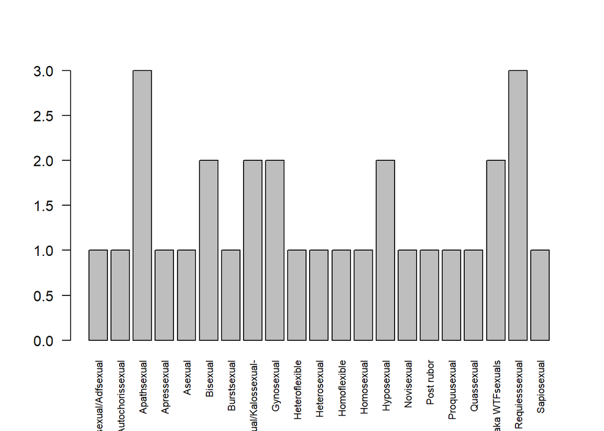

```r
tabla <- table(muestra)
barplot(tabla, las = 2, cex.names = 0.7)
```

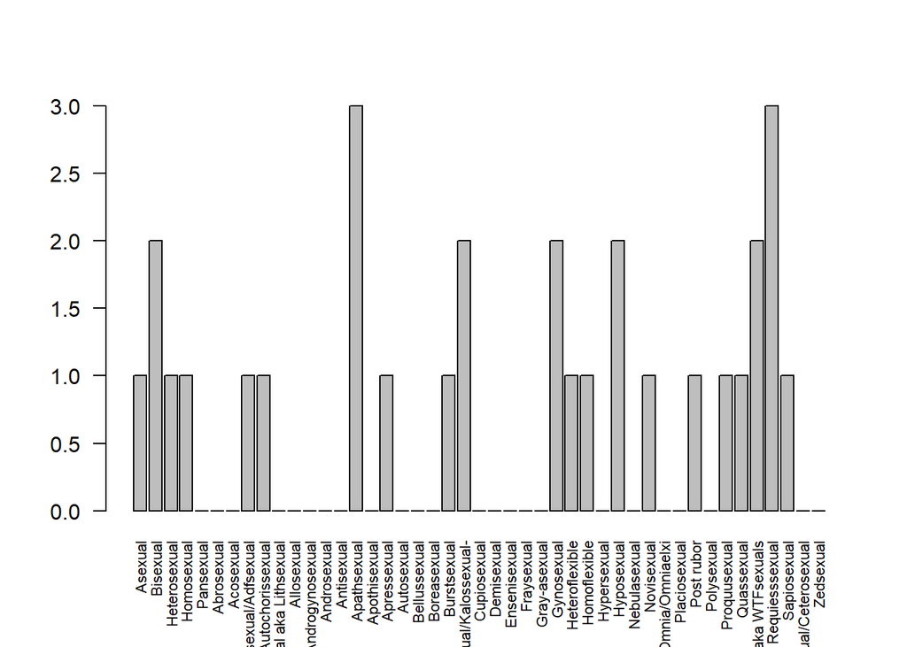

```r
muestra_factor <- factor(muestra, levels = unique(df$I_G))

# Estudiar la distribución de la muestra factorizada con el comando table y barplot
tabla_factor <- table(muestra_factor)
barplot(tabla_factor, las = 2, cex.names = 0.7)
```